# Selecting The Most Suitable 1x12 drivetrain for a road bike

Author: Nikolay Chehlarov

Date: 10.08.2021

# Problem description

A lot of bike riders are using data acquisition devices to log sensor data like GPS coordinates, heart rate, cadence and other. A biker is currently riding with 2x11 gear system (2 front chainrings and 11 rear cogs). The rider is considering an upgrade to 1x12 system to benefit from the latest developments in the industry.

The planned upgrade will change the available gear range and the number of possible gears will be reduced. The task of this study is to analyze the riding style of the rider from existing ride log and propose most suitable number of teeth for the 1x12 setup.

# Introduction

The rider of interest is currently using 2x11 Shimano drive system. The front chainrings are 50 and 34 teeth. The rear cassette is of range 11-28, or more precisely 11-12-13-14-15-17-19-21-23-25-28 teeth. The tyres are ETRTO 25-622 with circumference of 2.105m.

```python
import numpy as np
from datetime import datetime, timedelta
from typing import Dict, Union, Optional,Tuple
import matplotlib.pyplot as plt
import pandas as pd
import os
import fitdecode # requires "pip install fitdecode"
import seaborn as sns
import matplotlib.dates as mdates
from scipy.signal import savgol_filter
from scipy import interpolate
```

```python
TYRE_CIRCUMFERENCE = 2.105 # in m
CHAINRINGS = np.array([34, 50])
COGS = np.array([11, 12, 13, 14, 15, 17, 19, 21, 23, 25, 28])
```

# Data acquisition

The user uses a Garmin edge 530 device. A *.fit file is created for each ride. All fit files are collected in a folder. There are three ride types: mountain, road and on a stationary trainer. The analysis will be made on a road ride as the 1x12 upgrade is intended for the road bike.

## Exploring the *.fit files

A very good description is included into reference 2

```python
# Let's print what data we have in a random file
with fitdecode.FitReader(r'data - familiarization\2020-07-30-07-05-29.fit') as fit_file:
    for frame in fit_file:
        if isinstance(frame, fitdecode.records.FitDataMessage) and frame.name == 'record':
             # This frame contains data about a "track point".
            for field in frame.fields:
                print(field.name)
#there are also frame.name = 'lap', but they do not contain the information we need.
```

[output not shown]

[output cut: 37405 more lines]

```
timestamp
position_lat
position_long
distance
enhanced_altitude
altitude
enhanced_speed
speed
unknown_61
unknown_66
unknown_108
heart_rate
cadence
temperature
fractional_cadence
```

```python
RECORDS_COLUMN_NAMES = ['latitude', 'longitude', 'lap', 'altitude', 'timestamp', 'heart_rate', 'cadence', \
                       'speed', 'distance', 'temperature'] # data of interest
# "enhanced_speed", "enhanced_altitude", "fractional_cadence" do not have any additional information

def get_fit_data(frame: fitdecode.records.FitDataMessage) -> Optional[Dict[str, Union[float, int, str, datetime]]]:
    """
    Extracts data from a FIT frame, representing a track point
    and return it as a dict. Only activities with track are returned;
    stationary activities do not have latitude and longitude and the function returns None
    """
    data: Dict[str, Union[float, int, str, datetime]] = {}

    if not (frame.has_field('position_lat') and frame.has_field('position_long')):
        # Frame does not have any latitude or longitude data. Tthese frames will be ignored
        return None
    else:
        data['latitude'] = frame.get_value('position_lat') / ((2**32) / 360) #saved in degrees
        data['longitude'] = frame.get_value('position_long') / ((2**32) / 360) #saved in degrees

    for field in RECORDS_COLUMN_NAMES[3:]:
        if frame.has_field(field):
            data[field] = frame.get_value(field)

    return data


def get_dataframe(fname: str) -> Tuple[pd.DataFrame]:
    """
    Takes the path to a FIT file (as a string) and returns
    DataFrame, containing data about the individual records.
    """

    records_data = []
    lap_no = 1
    with fitdecode.FitReader(fname) as fit_file:
        for frame in fit_file:
            if isinstance(frame, fitdecode.records.FitDataMessage):
                if frame.name == 'record':
                    single_record_data = get_fit_data(frame)
                    if single_record_data is not None:
                        single_record_data['lap'] = lap_no
                        records_data.append(single_record_data)
                elif frame.name == 'lap':
                    lap_no += 1

    # Create DataFrames from the data we have collected. If any information is missing,
    # it will show up as a null value or "NaN" in the DataFrame.
    record_df = pd.DataFrame(records_data, columns=RECORDS_COLUMN_NAMES)

    return record_df

#unit testing
# path = r'data - familiarization\2020-07-30-07-05-29.fit' # Yambol
path = r'data - familiarization\2017-12-07-08-38-00.fit' # MTB Sofia ride
records_df = get_dataframe(path)
records_df
```

|  | latitude | longitude | lap | altitude | timestamp | heart_rate | cadence | speed | distance | temperature |
| --- | --- | --- | --- | --- | --- | --- | --- | --- | --- | --- |
| 0 | 42.671662 | 23.296266 | 1 | 627.0 | 2017-12-07 06:38:00+00:00 | 101 | NaN | 3.154 | 3.15 | 19 |
| 1 | 42.671611 | 23.296228 | 1 | 627.0 | 2017-12-07 06:38:02+00:00 | 105 | NaN | 3.695 | 10.30 | 19 |
| 2 | 42.671427 | 23.296056 | 1 | 627.6 | 2017-12-07 06:38:09+00:00 | 108 | NaN | 3.676 | 36.80 | 19 |
| 3 | 42.671311 | 23.295990 | 1 | 627.8 | 2017-12-07 06:38:13+00:00 | 112 | NaN | 3.508 | 50.81 | 19 |
| 4 | 42.671223 | 23.295955 | 1 | 628.4 | 2017-12-07 06:38:16+00:00 | 115 | NaN | 3.368 | 61.37 | 18 |
| ... | ... | ... | ... | ... | ... | ... | ... | ... | ... | ... |
| 1056 | 42.666676 | 23.324504 | 1 | 633.6 | 2017-12-07 07:52:53+00:00 | 128 | NaN | 4.124 | 17113.32 | 5 |
| 1057 | 42.666889 | 23.324399 | 1 | 633.8 | 2017-12-07 07:53:00+00:00 | 128 | NaN | 2.725 | 17136.80 | 5 |
| 1058 | 42.666954 | 23.324548 | 1 | 633.8 | 2017-12-07 07:53:06+00:00 | 125 | NaN | 2.603 | 17151.68 | 5 |
| 1059 | 42.666962 | 23.324638 | 1 | 633.8 | 2017-12-07 07:53:09+00:00 | 123 | NaN | 2.351 | 17159.17 | 5 |
| 1060 | 42.666944 | 23.324670 | 1 | 634.0 | 2017-12-07 07:53:11+00:00 | 123 | NaN | 0.000 | 17161.18 | 5 |

1061 rows × 10 columns

```python
def is_road_file(file_path):
    """
    Checks if the file contains data for a road ride
    """
    has_cadence = False
    with fitdecode.FitReader(file_path) as fit_file:
        for frame in fit_file:
            if isinstance(frame, fitdecode.records.FitDataMessage):
                if frame.name == 'device_info':
                    for field in frame.fields:
                        if field.name == "antplus_device_type":
                            if field.value == "fitness_equipment":
                                return False
                            if field.value == "bike_cadence":
                                #only the road bike has cadence sensor
                                has_cadence = True
                if frame.name == "record":
                    # we have checked the header
                    break
    return has_cadence

def get_all_road_rides(folder_path, single=True):
    """
    collects all road rides from a folder in a dataframe.
    if single==True the function creates a dataframe with only the first occurance of a road ride.
    """
    folder_road_rides = pd.DataFrame()
    for entry in os.scandir(folder_path):
        if entry.is_file and entry.name.split(".")[-1] == "fit":
            if is_road_file(entry.path):
                file_frame = get_dataframe(entry.path)
                average_speed = file_frame.speed.mean()
                average_cadance = file_frame.cadence.mean()
                distance = file_frame.distance.iloc[-1]
                print(f"""{entry.name}:
                    average speed = {average_speed}
                    average cadence = {average_cadance}
                    distance = {distance}""")
                folder_road_rides = pd.concat([folder_road_rides, file_frame], ignore_index=True)
                if single:
                    return folder_road_rides
    return folder_road_rides
```

# Exploratory Data Analysis (EDA)

## Data loading

One road ride is stored in the folder "data". It is loaded and inspected. The same ride is uploaded on https://www.strava.com/activities/5537229796 Comparison with the upload will be made.

```python
road_ride = get_all_road_rides(r"data - selected ride", single=True)
road_ride
```

```
2021-06-27-08-00-53.fit:
                    average speed = 7.703838172560895
                    average cadence = 63.287750865051905
                    distance = 165349.71
```

|  | latitude | longitude | lap | altitude | timestamp | heart_rate | cadence | speed | distance | temperature |
| --- | --- | --- | --- | --- | --- | --- | --- | --- | --- | --- |
| 0 | 42.671546 | 23.295498 | 1 | 583.4 | 2021-06-27 05:00:53+00:00 | 114.0 | 48.0 | 4.899 | 4.90 | 25 |
| 1 | 42.671560 | 23.295457 | 1 | 585.4 | 2021-06-27 05:00:54+00:00 | 115.0 | 48.0 | 4.731 | 9.63 | 25 |
| 2 | 42.671601 | 23.295406 | 1 | 585.6 | 2021-06-27 05:00:55+00:00 | 115.0 | 32.0 | 4.796 | 14.43 | 25 |
| 3 | 42.671631 | 23.295350 | 1 | 585.4 | 2021-06-27 05:00:56+00:00 | 115.0 | 32.0 | 4.796 | 19.22 | 25 |
| 4 | 42.671647 | 23.295305 | 1 | 585.4 | 2021-06-27 05:00:57+00:00 | 114.0 | 32.0 | 4.684 | 23.91 | 25 |
| ... | ... | ... | ... | ... | ... | ... | ... | ... | ... | ... |
| 7262 | 42.685635 | 23.138972 | 34 | 772.2 | 2021-06-27 11:57:12+00:00 | 124.0 | 25.0 | 1.110 | 165341.10 | 35 |
| 7263 | 42.685611 | 23.139020 | 34 | 772.2 | 2021-06-27 11:57:15+00:00 | 122.0 | 0.0 | 1.997 | 165346.33 | 35 |
| 7264 | 42.685612 | 23.139062 | 34 | 771.8 | 2021-06-27 11:57:17+00:00 | 120.0 | 0.0 | 1.381 | 165349.71 | 35 |
| 7265 | 42.685618 | 23.139071 | 34 | 771.8 | 2021-06-27 11:57:21+00:00 | 119.0 | 4.0 | 0.000 | 165349.71 | 35 |
| 7266 | 42.685618 | 23.139071 | 34 | 771.8 | 2021-06-27 11:57:26+00:00 | 120.0 | 0.0 | 0.000 | 165349.71 | 35 |

7267 rows × 10 columns

```python
road_ride.dtypes
```

```
latitude                   float64
longitude                  float64
lap                          int64
altitude                   float64
timestamp      datetime64[ns, UTC]
heart_rate                 float64
cadence                    float64
speed                      float64
distance                   float64
temperature                  int64
dtype: object
```

```python
road_ride.describe().T
```

|  | count | mean | std | min | 25% | 50% | 75% | max |
| --- | --- | --- | --- | --- | --- | --- | --- | --- |
| latitude | 7267.0 | 42.666341 | 0.046488 | 42.566613 | 42.626655 | 42.682601 | 42.706885 | 42.733819 |
| longitude | 7267.0 | 23.649968 | 0.247663 | 23.138662 | 23.436341 | 23.722136 | 23.860254 | 24.001795 |
| lap | 7267.0 | 17.209440 | 9.188901 | 1.000000 | 10.000000 | 17.000000 | 24.000000 | 34.000000 |
| altitude | 7267.0 | 663.015770 | 103.385607 | 510.200000 | 578.200000 | 637.200000 | 734.400000 | 924.200000 |
| heart_rate | 7249.0 | 139.485308 | 20.567335 | 72.000000 | 127.000000 | 142.000000 | 155.000000 | 179.000000 |
| cadence | 7225.0 | 63.287751 | 34.137560 | 0.000000 | 37.000000 | 80.000000 | 89.000000 | 114.000000 |
| speed | 7267.0 | 7.703838 | 3.842450 | 0.000000 | 4.600000 | 7.521000 | 10.245000 | 17.878000 |
| distance | 7267.0 | 83664.625826 | 46002.432023 | 4.900000 | 49117.565000 | 84490.640000 | 117117.800000 | 165349.710000 |
| temperature | 7267.0 | 26.899684 | 5.011793 | 19.000000 | 22.000000 | 26.000000 | 31.000000 | 38.000000 |

The data seems realistic and comparable with the analysis provided on Strava web page. The measuring units are as follows:

- latitude and longitude : °
- altitude : m
- heart_rate : bpm
- cadence : rpm
- speed : m/s (not km/h)
- distance : m
- temperature : °C

## Sampling rate

```python
def to_seconds(x):
    return x.total_seconds()


def add_duration(df):
    """
    Adds a column to the df containnig the duration of each record
    """
    sampling_time = df.timestamp.diff()
    sampling_time = pd.Series(sampling_time)
    sampling_time = df.timestamp.diff().apply(to_seconds)
    sampling_time.name = "duration"
    df = pd.concat([df, sampling_time], axis=1)
    return df


road_ride = add_duration(road_ride)
```

```python
sorted(road_ride.duration.unique())
```

```
[nan,
 1.0,
 2.0,
 3.0,
 4.0,
 5.0,
 6.0,
 7.0,
 8.0,
 9.0,
 10.0,
 11.0,
 12.0,
 13.0,
 14.0,
 15.0,
 16.0,
 17.0,
 18.0,
 19.0,
 20.0,
 21.0,
 22.0,
 23.0,
 25.0,
 26.0,
 28.0,
 31.0,
 50.0,
 1959.0]
```

The sampling is not every second. There is also one very long duration of 1959s. Let's try to find what is the logic.

```python
road_ride[road_ride.duration > 100]
```

|  | latitude | longitude | lap | altitude | timestamp | heart_rate | cadence | speed | distance | temperature | duration |
| --- | --- | --- | --- | --- | --- | --- | --- | --- | --- | --- | --- |
| 3925 | 42.655755 | 23.821555 | 18 | 730.2 | 2021-06-27 09:00:28+00:00 | 99.0 | 66.0 | 6.746 | 89618.22 | 26 | 1959.0 |

```python
road_ride[3920:3930]
```

|  | latitude | longitude | lap | altitude | timestamp | heart_rate | cadence | speed | distance | temperature | duration |
| --- | --- | --- | --- | --- | --- | --- | --- | --- | --- | --- | --- |
| 3920 | 42.655982 | 23.821497 | 18 | 728.2 | 2021-06-27 08:27:38+00:00 | 139.0 | 59.0 | 2.146 | 89611.47 | 26 | 4.0 |
| 3921 | 42.655976 | 23.821507 | 18 | 728.4 | 2021-06-27 08:27:39+00:00 | 138.0 | 59.0 | 0.000 | 89611.47 | 26 | 1.0 |
| 3922 | 42.655975 | 23.821510 | 18 | 728.4 | 2021-06-27 08:27:42+00:00 | 137.0 | 0.0 | 0.000 | 89611.47 | 26 | 3.0 |
| 3923 | 42.655975 | 23.821510 | 18 | 728.6 | 2021-06-27 08:27:43+00:00 | 137.0 | 0.0 | 0.000 | 89611.47 | 26 | 1.0 |
| 3924 | 42.655975 | 23.821510 | 18 | 729.0 | 2021-06-27 08:27:49+00:00 | 136.0 | 0.0 | 0.000 | 89611.47 | 26 | 6.0 |
| 3925 | 42.655755 | 23.821555 | 18 | 730.2 | 2021-06-27 09:00:28+00:00 | 99.0 | 66.0 | 6.746 | 89618.22 | 26 | 1959.0 |
| 3926 | 42.655718 | 23.821624 | 18 | 730.0 | 2021-06-27 09:00:29+00:00 | 101.0 | 66.0 | 7.437 | 89625.65 | 26 | 1.0 |
| 3927 | 42.655605 | 23.821860 | 18 | 729.8 | 2021-06-27 09:00:32+00:00 | 101.0 | 20.0 | 8.659 | 89650.44 | 26 | 3.0 |
| 3928 | 42.655513 | 23.822060 | 18 | 729.4 | 2021-06-27 09:00:34+00:00 | 101.0 | 0.0 | 9.293 | 89668.83 | 26 | 2.0 |
| 3929 | 42.655394 | 23.822349 | 18 | 728.6 | 2021-06-27 09:00:37+00:00 | NaN | 0.0 | 9.797 | 89698.07 | 26 | 3.0 |

Looking into the row with the highest duration and the GPS coordinates, we quickly realize the rider has been on a restaurant called "Ресторант No Names" in Google maps. It looks like the device manages logging frequency internally, most probably to preserve battery life.

```python
road_ride[road_ride.duration > 10].sample(10)
```

|  | latitude | longitude | lap | altitude | timestamp | heart_rate | cadence | speed | distance | temperature | duration |
| --- | --- | --- | --- | --- | --- | --- | --- | --- | --- | --- | --- |
| 4390 | 42.620165 | 23.763566 | 20 | 705.4 | 2021-06-27 09:20:46+00:00 | 120.0 | 0.0 | 0.0 | 98039.27 | 29 | 12.0 |
| 5150 | 42.567759 | 23.705447 | 22 | 852.6 | 2021-06-27 09:56:39+00:00 | 99.0 | 0.0 | 0.0 | 109597.11 | 29 | 12.0 |
| 558 | 42.706885 | 23.456879 | 3 | 529.2 | 2021-06-27 05:34:01+00:00 | 90.0 | 0.0 | 0.0 | 14647.95 | 20 | 11.0 |
| 3877 | 42.654290 | 23.822882 | 18 | 722.6 | 2021-06-27 08:25:31+00:00 | 115.0 | 0.0 | 0.0 | 89299.61 | 23 | 16.0 |
| 2499 | 42.702763 | 23.925129 | 12 | 776.4 | 2021-06-27 07:18:27+00:00 | 91.0 | 0.0 | 0.0 | 57370.51 | 24 | 13.0 |
| 2491 | 42.702763 | 23.925129 | 12 | 776.8 | 2021-06-27 07:17:11+00:00 | 92.0 | 0.0 | 0.0 | 57370.51 | 24 | 23.0 |
| 2492 | 42.702763 | 23.925129 | 12 | 776.8 | 2021-06-27 07:17:27+00:00 | 95.0 | 0.0 | 0.0 | 57370.51 | 24 | 16.0 |
| 1972 | 42.717119 | 23.874636 | 11 | 769.2 | 2021-06-27 06:58:48+00:00 | 109.0 | 0.0 | 0.0 | 51265.87 | 23 | 14.0 |
| 2498 | 42.702763 | 23.925129 | 12 | 776.8 | 2021-06-27 07:18:14+00:00 | 94.0 | 0.0 | 0.0 | 57370.51 | 24 | 19.0 |
| 584 | 42.706885 | 23.456884 | 3 | 529.0 | 2021-06-27 05:37:14+00:00 | 81.0 | 0.0 | 0.0 | 14647.95 | 20 | 21.0 |

The device increases logging time when the speed and cadence are 0. Entries with long duration might poison the analysis, they also do not add value as the rider is not moving, hence not using the gears. The topic will be discussed in distance section.

```python
road_ride[(road_ride.duration > 10) & (road_ride.speed > 0)]
```

|  | latitude | longitude | lap | altitude | timestamp | heart_rate | cadence | speed | distance | temperature | duration |
| --- | --- | --- | --- | --- | --- | --- | --- | --- | --- | --- | --- |
| 286 | 42.697928 | 23.360775 | 2 | 529.2 | 2021-06-27 05:13:50+00:00 | 136.0 | 32.0 | 9.583 | 6625.03 | 20 | 12.0 |
| 354 | 42.699766 | 23.369178 | 2 | 530.6 | 2021-06-27 05:19:39+00:00 | 93.0 | 0.0 | 3.630 | 7336.82 | 22 | 14.0 |
| 1975 | 42.717120 | 23.874638 | 11 | 768.8 | 2021-06-27 06:59:12+00:00 | 106.0 | 0.0 | 0.961 | 51266.98 | 23 | 17.0 |
| 3925 | 42.655755 | 23.821555 | 18 | 730.2 | 2021-06-27 09:00:28+00:00 | 99.0 | 66.0 | 6.746 | 89618.22 | 26 | 1959.0 |
| 6393 | 42.700023 | 23.310318 | 30 | 555.0 | 2021-06-27 11:05:01+00:00 | 119.0 | 43.0 | 4.861 | 148022.94 | 33 | 20.0 |
| 6534 | 42.709744 | 23.273300 | 31 | 578.8 | 2021-06-27 11:13:45+00:00 | 164.0 | 91.0 | 10.460 | 151294.11 | 34 | 50.0 |

## Heart rate

```python
# road_ride.heart_rate.unique()
```

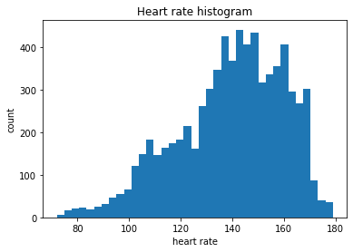

```python
plt.hist(road_ride.heart_rate, bins="fd")
plt.title("Heart rate histogram")
plt.xlabel("heart rate")
plt.ylabel("count")
plt.show()
```

```python
road_ride[pd.isna(road_ride.heart_rate)]
```

|  | latitude | longitude | lap | altitude | timestamp | heart_rate | cadence | speed | distance | temperature | duration |
| --- | --- | --- | --- | --- | --- | --- | --- | --- | --- | --- | --- |
| 316 | 42.699740 | 23.368918 | 2 | 531.2 | 2021-06-27 05:15:33+00:00 | NaN | 0.0 | 4.852 | 7307.23 | 20 | 1.0 |
| 2365 | 42.703722 | 23.912650 | 12 | 872.2 | 2021-06-27 07:12:30+00:00 | NaN | 33.0 | 14.882 | 55790.76 | 21 | 2.0 |
| 2384 | 42.703427 | 23.916309 | 12 | 848.4 | 2021-06-27 07:12:56+00:00 | NaN | 0.0 | 13.688 | 56163.61 | 21 | 1.0 |
| 2385 | 42.703408 | 23.916463 | 12 | 847.2 | 2021-06-27 07:12:57+00:00 | NaN | 0.0 | 14.052 | 56177.66 | 21 | 1.0 |
| 2395 | 42.702626 | 23.918040 | 12 | 837.6 | 2021-06-27 07:13:08+00:00 | NaN | 0.0 | 15.498 | 56341.18 | 21 | 1.0 |
| 2396 | 42.702669 | 23.918225 | 12 | 836.4 | 2021-06-27 07:13:09+00:00 | NaN | 0.0 | 15.704 | 56356.88 | 21 | 1.0 |
| 2427 | 42.702594 | 23.922981 | 12 | 804.2 | 2021-06-27 07:13:47+00:00 | NaN | 0.0 | 15.414 | 56929.23 | 22 | 1.0 |
| 2428 | 42.702431 | 23.923335 | 12 | 802.2 | 2021-06-27 07:13:49+00:00 | NaN | 0.0 | 15.256 | 56959.74 | 22 | 2.0 |
| 2453 | 42.702987 | 23.924390 | 12 | 784.0 | 2021-06-27 07:14:18+00:00 | NaN | 0.0 | 9.751 | 57298.08 | 22 | 1.0 |
| 2454 | 42.703046 | 23.924475 | 12 | 783.4 | 2021-06-27 07:14:19+00:00 | NaN | 0.0 | 8.640 | 57306.72 | 22 | 1.0 |
| 2564 | 42.696529 | 23.932359 | 12 | 730.4 | 2021-06-27 07:20:32+00:00 | NaN | 0.0 | 13.940 | 58387.19 | 26 | 1.0 |
| 2565 | 42.696425 | 23.932448 | 12 | 729.8 | 2021-06-27 07:20:33+00:00 | NaN | 0.0 | 14.603 | 58401.80 | 26 | 1.0 |
| 2566 | 42.696315 | 23.932508 | 12 | 728.8 | 2021-06-27 07:20:34+00:00 | NaN | 0.0 | 14.864 | 58416.65 | 26 | 1.0 |
| 2579 | 42.695024 | 23.930141 | 12 | 713.2 | 2021-06-27 07:20:50+00:00 | NaN | 95.0 | 15.050 | 58663.46 | 26 | 2.0 |
| 2588 | 42.694539 | 23.928937 | 12 | 707.0 | 2021-06-27 07:21:00+00:00 | NaN | 0.0 | 11.710 | 58790.51 | 26 | 1.0 |
| 3929 | 42.655394 | 23.822349 | 18 | 728.6 | 2021-06-27 09:00:37+00:00 | NaN | 0.0 | 9.797 | 89698.07 | 26 | 3.0 |
| 3930 | 42.655363 | 23.822462 | 18 | 728.2 | 2021-06-27 09:00:38+00:00 | NaN | 0.0 | 9.797 | 89707.86 | 26 | 1.0 |
| 4152 | 42.628671 | 23.807058 | 19 | 666.4 | 2021-06-27 09:09:17+00:00 | NaN | 34.0 | 14.687 | 93387.46 | 30 | 1.0 |

There are some missing hear rate entries, most probably due to device communication issue or bad electrical contact to the body. The amount of missing data is low and it is also not essential for the defined problem.

Heart rate could be used for some approximation for power. Due to physiological reasons, the heart rate has significant lag from power output. If power meter was fitted, it could bring a lot of valuable information.

## Cadence

```python
# np.sort(road_ride.cadence.unique())
```

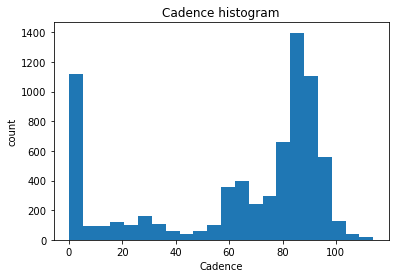

```python
plt.hist(road_ride.cadence, bins="fd")
plt.title("Cadence histogram")
plt.xlabel("Cadence")
plt.ylabel("count")
plt.show()
```

```python
road_ride[pd.isna(road_ride.cadence)]
```

|  | latitude | longitude | lap | altitude | timestamp | heart_rate | cadence | speed | distance | temperature | duration |
| --- | --- | --- | --- | --- | --- | --- | --- | --- | --- | --- | --- |
| 605 | 42.706885 | 23.456884 | 3 | 528.8 | 2021-06-27 05:39:43+00:00 | 77.0 | NaN | 0.000 | 14647.95 | 20 | 4.0 |
| 606 | 42.706885 | 23.456884 | 3 | 529.0 | 2021-06-27 05:40:03+00:00 | 81.0 | NaN | 0.000 | 14647.95 | 20 | 20.0 |
| 607 | 42.706885 | 23.456884 | 3 | 529.0 | 2021-06-27 05:40:06+00:00 | 85.0 | NaN | 0.000 | 14647.95 | 20 | 3.0 |
| 608 | 42.706885 | 23.456884 | 3 | 528.6 | 2021-06-27 05:40:37+00:00 | 82.0 | NaN | 0.000 | 14647.95 | 20 | 31.0 |
| 609 | 42.706885 | 23.456884 | 3 | 528.6 | 2021-06-27 05:40:45+00:00 | 79.0 | NaN | 0.000 | 14647.95 | 20 | 8.0 |
| 610 | 42.706885 | 23.456884 | 3 | 528.6 | 2021-06-27 05:40:49+00:00 | 76.0 | NaN | 0.000 | 14647.95 | 20 | 4.0 |
| 611 | 42.706885 | 23.456884 | 3 | 528.6 | 2021-06-27 05:40:53+00:00 | 79.0 | NaN | 0.000 | 14647.95 | 20 | 4.0 |
| 612 | 42.706885 | 23.456884 | 3 | 528.6 | 2021-06-27 05:41:05+00:00 | 76.0 | NaN | 0.000 | 14647.95 | 20 | 12.0 |
| 613 | 42.706885 | 23.456884 | 3 | 528.6 | 2021-06-27 05:41:08+00:00 | 73.0 | NaN | 0.000 | 14647.95 | 20 | 3.0 |
| 614 | 42.706885 | 23.456884 | 3 | 528.6 | 2021-06-27 05:41:14+00:00 | 76.0 | NaN | 0.000 | 14647.95 | 20 | 6.0 |
| 615 | 42.706885 | 23.456884 | 3 | 528.6 | 2021-06-27 05:41:26+00:00 | 73.0 | NaN | 0.000 | 14647.95 | 20 | 12.0 |
| 616 | 42.706885 | 23.456884 | 3 | 528.6 | 2021-06-27 05:41:45+00:00 | 77.0 | NaN | 0.000 | 14647.95 | 20 | 19.0 |
| 617 | 42.706885 | 23.456884 | 3 | 528.6 | 2021-06-27 05:41:46+00:00 | 78.0 | NaN | 0.000 | 14647.95 | 20 | 1.0 |
| 618 | 42.706885 | 23.456884 | 3 | 528.6 | 2021-06-27 05:42:11+00:00 | 75.0 | NaN | 0.000 | 14647.95 | 20 | 25.0 |
| 619 | 42.706885 | 23.456884 | 3 | 528.6 | 2021-06-27 05:42:17+00:00 | 72.0 | NaN | 0.000 | 14647.95 | 20 | 6.0 |
| 620 | 42.706885 | 23.456884 | 3 | 528.4 | 2021-06-27 05:42:42+00:00 | 75.0 | NaN | 0.000 | 14647.95 | 20 | 25.0 |
| 621 | 42.706885 | 23.456884 | 3 | 528.4 | 2021-06-27 05:42:45+00:00 | 78.0 | NaN | 0.000 | 14647.95 | 20 | 3.0 |
| 622 | 42.706885 | 23.456884 | 3 | 528.4 | 2021-06-27 05:42:47+00:00 | 81.0 | NaN | 0.000 | 14647.95 | 20 | 2.0 |
| 623 | 42.706885 | 23.456884 | 3 | 528.4 | 2021-06-27 05:42:59+00:00 | 78.0 | NaN | 0.000 | 14647.95 | 20 | 12.0 |
| 624 | 42.706885 | 23.456884 | 3 | 528.6 | 2021-06-27 05:43:07+00:00 | 81.0 | NaN | 0.000 | 14647.95 | 20 | 8.0 |
| 625 | 42.706885 | 23.456884 | 3 | 528.4 | 2021-06-27 05:43:21+00:00 | 78.0 | NaN | 0.000 | 14647.95 | 20 | 14.0 |
| 626 | 42.706885 | 23.456884 | 3 | 528.4 | 2021-06-27 05:43:24+00:00 | 75.0 | NaN | 0.000 | 14647.95 | 20 | 3.0 |
| 627 | 42.706885 | 23.456884 | 3 | 528.4 | 2021-06-27 05:43:29+00:00 | 72.0 | NaN | 0.000 | 14647.95 | 20 | 5.0 |
| 628 | 42.706885 | 23.456884 | 3 | 528.4 | 2021-06-27 05:43:39+00:00 | 75.0 | NaN | 0.000 | 14647.95 | 20 | 10.0 |
| 629 | 42.706885 | 23.456884 | 3 | 528.4 | 2021-06-27 05:43:56+00:00 | 78.0 | NaN | 0.000 | 14647.95 | 20 | 17.0 |
| 630 | 42.706885 | 23.456884 | 3 | 528.4 | 2021-06-27 05:44:06+00:00 | 81.0 | NaN | 0.000 | 14647.95 | 20 | 10.0 |
| 631 | 42.706885 | 23.456884 | 3 | 528.2 | 2021-06-27 05:44:10+00:00 | 85.0 | NaN | 0.000 | 14647.95 | 20 | 4.0 |
| 632 | 42.706885 | 23.456884 | 3 | 528.2 | 2021-06-27 05:44:38+00:00 | 82.0 | NaN | 0.000 | 14647.95 | 20 | 28.0 |
| 633 | 42.706885 | 23.456884 | 3 | 528.2 | 2021-06-27 05:44:41+00:00 | 79.0 | NaN | 0.000 | 14647.95 | 20 | 3.0 |
| 634 | 42.706885 | 23.456884 | 3 | 528.0 | 2021-06-27 05:44:50+00:00 | 76.0 | NaN | 0.000 | 14647.95 | 20 | 9.0 |
| 635 | 42.706885 | 23.456884 | 3 | 527.8 | 2021-06-27 05:45:02+00:00 | 79.0 | NaN | 0.000 | 14647.95 | 20 | 12.0 |
| 636 | 42.706885 | 23.456884 | 3 | 527.8 | 2021-06-27 05:45:06+00:00 | 82.0 | NaN | 0.000 | 14647.95 | 20 | 4.0 |
| 637 | 42.706885 | 23.456884 | 3 | 528.0 | 2021-06-27 05:45:16+00:00 | 79.0 | NaN | 0.000 | 14647.95 | 20 | 10.0 |
| 638 | 42.706885 | 23.456884 | 3 | 528.0 | 2021-06-27 05:45:19+00:00 | 76.0 | NaN | 0.000 | 14647.95 | 20 | 3.0 |
| 639 | 42.706885 | 23.456884 | 3 | 528.0 | 2021-06-27 05:45:28+00:00 | 81.0 | NaN | 0.000 | 14647.95 | 20 | 9.0 |
| 640 | 42.706885 | 23.456884 | 3 | 528.0 | 2021-06-27 05:45:42+00:00 | 78.0 | NaN | 0.000 | 14647.95 | 20 | 14.0 |
| 641 | 42.706885 | 23.456884 | 3 | 528.0 | 2021-06-27 05:45:45+00:00 | 75.0 | NaN | 0.000 | 14647.95 | 20 | 3.0 |
| 642 | 42.706885 | 23.456884 | 3 | 528.0 | 2021-06-27 05:45:51+00:00 | 72.0 | NaN | 0.000 | 14647.95 | 20 | 6.0 |
| 643 | 42.706886 | 23.456884 | 3 | 528.0 | 2021-06-27 05:45:56+00:00 | 77.0 | NaN | 0.000 | 14648.05 | 20 | 5.0 |
| 644 | 42.706913 | 23.456874 | 3 | 528.0 | 2021-06-27 05:45:58+00:00 | 82.0 | NaN | 2.351 | 14652.93 | 20 | 2.0 |
| 645 | 42.706925 | 23.456858 | 3 | 528.0 | 2021-06-27 05:45:59+00:00 | 83.0 | NaN | 2.678 | 14655.61 | 20 | 1.0 |
| 646 | 42.706938 | 23.456839 | 3 | 528.0 | 2021-06-27 05:46:00+00:00 | 85.0 | NaN | 2.725 | 14658.33 | 20 | 1.0 |

```python
road_ride[640:655]
```

|  | latitude | longitude | lap | altitude | timestamp | heart_rate | cadence | speed | distance | temperature | duration |
| --- | --- | --- | --- | --- | --- | --- | --- | --- | --- | --- | --- |
| 640 | 42.706885 | 23.456884 | 3 | 528.0 | 2021-06-27 05:45:42+00:00 | 78.0 | NaN | 0.000 | 14647.95 | 20 | 14.0 |
| 641 | 42.706885 | 23.456884 | 3 | 528.0 | 2021-06-27 05:45:45+00:00 | 75.0 | NaN | 0.000 | 14647.95 | 20 | 3.0 |
| 642 | 42.706885 | 23.456884 | 3 | 528.0 | 2021-06-27 05:45:51+00:00 | 72.0 | NaN | 0.000 | 14647.95 | 20 | 6.0 |
| 643 | 42.706886 | 23.456884 | 3 | 528.0 | 2021-06-27 05:45:56+00:00 | 77.0 | NaN | 0.000 | 14648.05 | 20 | 5.0 |
| 644 | 42.706913 | 23.456874 | 3 | 528.0 | 2021-06-27 05:45:58+00:00 | 82.0 | NaN | 2.351 | 14652.93 | 20 | 2.0 |
| 645 | 42.706925 | 23.456858 | 3 | 528.0 | 2021-06-27 05:45:59+00:00 | 83.0 | NaN | 2.678 | 14655.61 | 20 | 1.0 |
| 646 | 42.706938 | 23.456839 | 3 | 528.0 | 2021-06-27 05:46:00+00:00 | 85.0 | NaN | 2.725 | 14658.33 | 20 | 1.0 |
| 647 | 42.706953 | 23.456819 | 3 | 528.0 | 2021-06-27 05:46:01+00:00 | 88.0 | 0.0 | 3.079 | 14661.41 | 20 | 1.0 |
| 648 | 42.707001 | 23.456792 | 3 | 528.0 | 2021-06-27 05:46:03+00:00 | 91.0 | 0.0 | 2.622 | 14666.92 | 20 | 2.0 |
| 649 | 42.707052 | 23.456800 | 3 | 528.0 | 2021-06-27 05:46:05+00:00 | 94.0 | 0.0 | 3.210 | 14672.97 | 20 | 2.0 |
| 650 | 42.707092 | 23.456905 | 3 | 528.0 | 2021-06-27 05:46:08+00:00 | 97.0 | 50.0 | 4.777 | 14685.52 | 20 | 3.0 |
| 651 | 42.707105 | 23.457081 | 3 | 528.0 | 2021-06-27 05:46:11+00:00 | 101.0 | 60.0 | 5.794 | 14701.98 | 20 | 3.0 |
| 652 | 42.707106 | 23.457152 | 3 | 528.0 | 2021-06-27 05:46:12+00:00 | 101.0 | 60.0 | 6.130 | 14708.11 | 20 | 1.0 |
| 653 | 42.707105 | 23.457294 | 3 | 528.0 | 2021-06-27 05:46:14+00:00 | 104.0 | 61.0 | 6.559 | 14721.05 | 20 | 2.0 |
| 654 | 42.707106 | 23.457447 | 3 | 528.2 | 2021-06-27 05:46:16+00:00 | 107.0 | 61.0 | 6.298 | 14733.68 | 20 | 2.0 |

There are some entries for cadence with nan value. These values are recorded when the cranks are not rotated. The nan values become 0 and than return to normal. Checking the GPS coordinates reveals that this is a gas station, where the teammates has met for the ride. The bike was not moving.

```python
road_ride[(road_ride.cadence == 0) & (road_ride.speed > 0)]
```

|  | latitude | longitude | lap | altitude | timestamp | heart_rate | cadence | speed | distance | temperature | duration |
| --- | --- | --- | --- | --- | --- | --- | --- | --- | --- | --- | --- |
| 6 | 42.671719 | 23.295143 | 1 | 585.2 | 2021-06-27 05:01:00+00:00 | 110.0 | 0.0 | 4.581 | 37.78 | 25 | 2.0 |
| 7 | 42.671739 | 23.295108 | 1 | 585.4 | 2021-06-27 05:01:01+00:00 | 109.0 | 0.0 | 4.563 | 42.35 | 25 | 1.0 |
| 8 | 42.671772 | 23.295050 | 1 | 585.0 | 2021-06-27 05:01:02+00:00 | 108.0 | 0.0 | 4.563 | 46.91 | 25 | 1.0 |
| 9 | 42.671810 | 23.294953 | 1 | 584.8 | 2021-06-27 05:01:04+00:00 | 108.0 | 0.0 | 5.020 | 56.80 | 25 | 2.0 |
| 20 | 42.672510 | 23.295226 | 1 | 584.8 | 2021-06-27 05:01:22+00:00 | 105.0 | 0.0 | 6.186 | 148.08 | 25 | 2.0 |
| ... | ... | ... | ... | ... | ... | ... | ... | ... | ... | ... | ... |
| 7012 | 42.706526 | 23.153673 | 33 | 642.0 | 2021-06-27 11:43:08+00:00 | 138.0 | 0.0 | 6.933 | 162130.74 | 35 | 3.0 |
| 7035 | 42.705199 | 23.148504 | 33 | 644.0 | 2021-06-27 11:44:25+00:00 | 127.0 | 0.0 | 1.652 | 162588.24 | 35 | 4.0 |
| 7036 | 42.705197 | 23.148478 | 33 | 644.2 | 2021-06-27 11:44:27+00:00 | 124.0 | 0.0 | 1.297 | 162590.35 | 35 | 2.0 |
| 7263 | 42.685611 | 23.139020 | 34 | 772.2 | 2021-06-27 11:57:15+00:00 | 122.0 | 0.0 | 1.997 | 165346.33 | 35 | 3.0 |
| 7264 | 42.685612 | 23.139062 | 34 | 771.8 | 2021-06-27 11:57:17+00:00 | 120.0 | 0.0 | 1.381 | 165349.71 | 35 | 2.0 |

789 rows × 11 columns

There are a lot of entries when the bike is moving by inertia and the cranks are not rotated. This is called "freewheeling".

```python
road_ride[(road_ride.cadence > 0) & (road_ride.cadence < 30)] # this range is untypical, low cadence
```

|  | latitude | longitude | lap | altitude | timestamp | heart_rate | cadence | speed | distance | temperature | duration |
| --- | --- | --- | --- | --- | --- | --- | --- | --- | --- | --- | --- |
| 10 | 42.671826 | 23.294951 | 1 | 585.0 | 2021-06-27 05:01:05+00:00 | 108.0 | 25.0 | 5.197 | 61.99 | 25 | 1.0 |
| 11 | 42.671919 | 23.295020 | 1 | 585.0 | 2021-06-27 05:01:08+00:00 | 107.0 | 25.0 | 5.729 | 79.08 | 25 | 3.0 |
| 12 | 42.671975 | 23.294993 | 1 | 585.0 | 2021-06-27 05:01:09+00:00 | 107.0 | 25.0 | 5.561 | 84.64 | 25 | 1.0 |
| 13 | 42.672063 | 23.294997 | 1 | 585.0 | 2021-06-27 05:01:11+00:00 | 107.0 | 25.0 | 5.365 | 95.55 | 25 | 2.0 |
| 14 | 42.672109 | 23.295174 | 1 | 585.0 | 2021-06-27 05:01:12+00:00 | 107.0 | 14.0 | 5.244 | 100.79 | 25 | 1.0 |
| ... | ... | ... | ... | ... | ... | ... | ... | ... | ... | ... | ... |
| 7154 | 42.695021 | 23.148388 | 33 | 711.0 | 2021-06-27 11:50:36+00:00 | 141.0 | 21.0 | 4.311 | 163994.40 | 33 | 4.0 |
| 7260 | 42.685669 | 23.138902 | 34 | 772.2 | 2021-06-27 11:57:08+00:00 | 129.0 | 25.0 | 2.771 | 165334.41 | 35 | 3.0 |
| 7261 | 42.685640 | 23.138962 | 34 | 772.2 | 2021-06-27 11:57:11+00:00 | 125.0 | 25.0 | 1.110 | 165339.99 | 35 | 3.0 |
| 7262 | 42.685635 | 23.138972 | 34 | 772.2 | 2021-06-27 11:57:12+00:00 | 124.0 | 25.0 | 1.110 | 165341.10 | 35 | 1.0 |
| 7265 | 42.685618 | 23.139071 | 34 | 771.8 | 2021-06-27 11:57:21+00:00 | 119.0 | 4.0 | 0.000 | 165349.71 | 35 | 4.0 |

543 rows × 11 columns

```python
# road_ride[17:25]
```

```python
# road_ride[90:110]
```

```python
# road_ride[270:280]
```

```python
road_ride[(road_ride.cadence > 0) & (road_ride.cadence < 30)].sample(20)
```

|  | latitude | longitude | lap | altitude | timestamp | heart_rate | cadence | speed | distance | temperature | duration |
| --- | --- | --- | --- | --- | --- | --- | --- | --- | --- | --- | --- |
| 4462 | 42.619234 | 23.747708 | 20 | 652.6 | 2021-06-27 09:23:35+00:00 | 116.0 | 16.0 | 12.531 | 99621.19 | 29 | 1.0 |
| 2575 | 42.695417 | 23.931431 | 12 | 720.6 | 2021-06-27 07:20:43+00:00 | 103.0 | 21.0 | 15.676 | 58556.17 | 26 | 1.0 |
| 1831 | 42.715199 | 23.854720 | 10 | 708.8 | 2021-06-27 06:52:32+00:00 | 137.0 | 29.0 | 11.057 | 49482.59 | 23 | 3.0 |
| 13 | 42.672063 | 23.294997 | 1 | 585.0 | 2021-06-27 05:01:11+00:00 | 107.0 | 25.0 | 5.365 | 95.55 | 25 | 2.0 |
| 4902 | 42.584620 | 23.725138 | 22 | 846.2 | 2021-06-27 09:43:26+00:00 | 153.0 | 6.0 | 10.366 | 105617.35 | 30 | 1.0 |
| 4424 | 42.616747 | 23.758969 | 20 | 689.4 | 2021-06-27 09:22:16+00:00 | 109.0 | 4.0 | 10.917 | 98658.84 | 29 | 1.0 |
| 5384 | 42.589878 | 23.663962 | 23 | 696.4 | 2021-06-27 10:06:16+00:00 | 135.0 | 28.0 | 14.528 | 114912.57 | 28 | 1.0 |
| 1701 | 42.733231 | 23.807071 | 9 | 753.6 | 2021-06-27 06:46:16+00:00 | 104.0 | 11.0 | 16.207 | 44942.01 | 21 | 2.0 |
| 308 | 42.699173 | 23.365889 | 2 | 530.4 | 2021-06-27 05:14:59+00:00 | 139.0 | 25.0 | 7.679 | 7056.25 | 20 | 1.0 |
| 5636 | 42.607649 | 23.583894 | 25 | 625.4 | 2021-06-27 10:18:46+00:00 | 130.0 | 5.0 | 11.682 | 122431.40 | 31 | 4.0 |
| 2961 | 42.627577 | 23.998055 | 15 | 536.2 | 2021-06-27 07:37:18+00:00 | 144.0 | 17.0 | 8.640 | 70341.59 | 27 | 3.0 |
| 288 | 42.698069 | 23.360988 | 2 | 529.2 | 2021-06-27 05:13:52+00:00 | 137.0 | 14.0 | 9.172 | 6643.50 | 20 | 1.0 |
| 249 | 42.696808 | 23.353726 | 2 | 536.4 | 2021-06-27 05:12:15+00:00 | 131.0 | 27.0 | 6.298 | 6001.06 | 19 | 3.0 |
| 5324 | 42.584600 | 23.669949 | 23 | 763.8 | 2021-06-27 10:04:56+00:00 | 114.0 | 5.0 | 14.584 | 113697.11 | 28 | 1.0 |
| 369 | 42.700293 | 23.372014 | 2 | 532.0 | 2021-06-27 05:20:12+00:00 | 129.0 | 21.0 | 8.034 | 7580.67 | 22 | 2.0 |
| 5757 | 42.621633 | 23.536446 | 26 | 586.4 | 2021-06-27 10:25:08+00:00 | 143.0 | 17.0 | 12.233 | 126710.72 | 32 | 1.0 |
| 2770 | 42.671711 | 23.992988 | 13 | 603.8 | 2021-06-27 07:28:51+00:00 | 135.0 | 18.0 | 10.730 | 64794.16 | 27 | 1.0 |
| 4185 | 42.623762 | 23.805129 | 19 | 646.4 | 2021-06-27 09:10:23+00:00 | 123.0 | 7.0 | 11.113 | 94158.59 | 29 | 2.0 |
| 3734 | 42.644111 | 23.852120 | 18 | 769.2 | 2021-06-27 08:19:48+00:00 | 141.0 | 26.0 | 11.076 | 86237.57 | 24 | 5.0 |
| 1401 | 42.722831 | 23.772199 | 9 | 628.6 | 2021-06-27 06:34:21+00:00 | 107.0 | 21.0 | 7.063 | 41122.33 | 22 | 6.0 |

There are a moderate amount of entries with low cadence. Picking random samples and checking the GPS coordinates, indicates most of them are in urban areas where the rider has to adapt to signal lights and road traffic. This rates happen during acceleration from a stop when too high gear is engaged. Other possible use of low cadence is during out of the saddle efforts.

## Speed

```python
pd.isna(road_ride.speed).any()
```

```
False
```

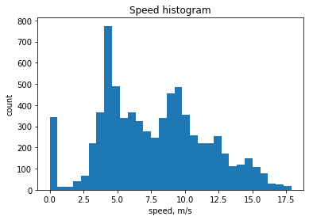

```python
plt.hist(road_ride.speed, bins="fd")
plt.title("Speed histogram")
plt.xlabel("speed, m/s")
plt.ylabel("count")
plt.show()
```

Every entry has a speed value, that could be 0m/s. Speed is determined from a sensor attached to the front hub.

## Distance

There are three possible ways to get the distance

- use the existing column in the dataframe
- by integrating speed over time
- by calculating the length of the GPS track.

Integration over the speed will be performed to compare the results.

```python
def add_distance_increment(df):
    """
    Adds a column with distance incrments
    """
    distance_increment = df.distance.diff()
    distance_increment.name = "distance_increment"
    df = pd.concat([df, distance_increment], axis=1)
    return df

road_ride = add_distance_increment(road_ride)
```

```python
def add_speed_mult_duration(df):
    """
    Adds a column with distance incrments caclulated from v*t for each row
    """
    df["v_mult_t"] = df.speed * df.duration
    return df

road_ride = add_speed_mult_duration(road_ride)
```

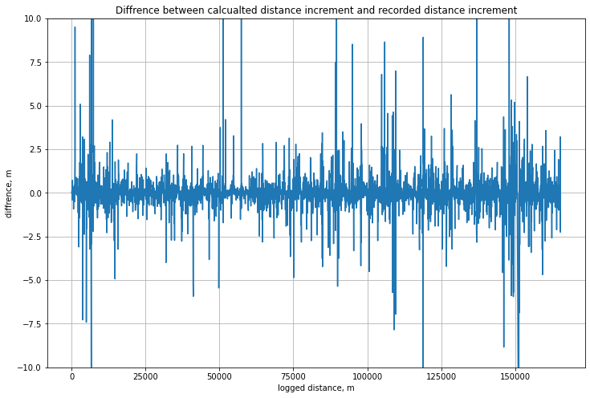

```python
# plot are there significant diffrecne between both approached
plt.figure(figsize=(12,8))
plt.plot(road_ride.distance, road_ride.v_mult_t - road_ride.distance_increment )
plt.title("Diffrence between calcualted distance increment and recorded distance increment")
plt.xlabel("logged distance, m")
plt.ylabel("diffrence, m")
# plt.gca().set_aspect('equal')
plt.ylim(-10, 10)
plt.grid()
plt.show()
```

The outliers are individuals and not grouped in series. They will be removed form the dataframe. It is expected the distance increment form the distance log created by Garmin software to be more accurate and will be used. (maybe the difference is due to resolution of the recordings)

```python
road_ride[ abs(road_ride.v_mult_t - road_ride.distance_increment) > 8 ]
```

|  | latitude | longitude | lap | altitude | timestamp | heart_rate | cadence | speed | distance | temperature | duration | distance_increment | v_mult_t |
| --- | --- | --- | --- | --- | --- | --- | --- | --- | --- | --- | --- | --- | --- |
| 55 | 42.679143 | 23.301842 | 1 | 575.4 | 2021-06-27 05:03:05+00:00 | 133.0 | 94.0 | 9.573 | 1115.71 | 22 | 3.0 | 19.21 | 28.719 |
| 286 | 42.697928 | 23.360775 | 2 | 529.2 | 2021-06-27 05:13:50+00:00 | 136.0 | 32.0 | 9.583 | 6625.03 | 20 | 12.0 | 127.75 | 114.996 |
| 296 | 42.698443 | 23.362043 | 2 | 529.4 | 2021-06-27 05:14:15+00:00 | 120.0 | 0.0 | 3.798 | 6727.39 | 20 | 5.0 | 8.67 | 18.990 |
| 354 | 42.699766 | 23.369178 | 2 | 530.6 | 2021-06-27 05:19:39+00:00 | 93.0 | 0.0 | 3.630 | 7336.82 | 22 | 14.0 | 11.85 | 50.820 |
| 1975 | 42.717120 | 23.874638 | 11 | 768.8 | 2021-06-27 06:59:12+00:00 | 106.0 | 0.0 | 0.961 | 51266.98 | 23 | 17.0 | 1.11 | 16.337 |
| 2509 | 42.702767 | 23.925169 | 12 | 775.0 | 2021-06-27 07:19:08+00:00 | 87.0 | 0.0 | 2.687 | 57374.18 | 25 | 10.0 | 2.79 | 26.870 |
| 3925 | 42.655755 | 23.821555 | 18 | 730.2 | 2021-06-27 09:00:28+00:00 | 99.0 | 66.0 | 6.746 | 89618.22 | 26 | 1959.0 | 6.75 | 13215.414 |
| 4218 | 42.620981 | 23.796300 | 19 | 635.4 | 2021-06-27 09:11:46+00:00 | 127.0 | 96.0 | 9.536 | 94958.86 | 29 | 5.0 | 39.16 | 47.680 |
| 4916 | 42.582133 | 23.724642 | 22 | 838.2 | 2021-06-27 09:44:04+00:00 | 137.0 | 0.0 | 7.455 | 105916.32 | 30 | 8.0 | 50.99 | 59.640 |
| 5512 | 42.603824 | 23.625173 | 24 | 642.8 | 2021-06-27 10:12:02+00:00 | 156.0 | 14.0 | 3.368 | 118936.17 | 29 | 7.0 | 38.49 | 23.576 |
| 5518 | 42.603843 | 23.625025 | 24 | 642.8 | 2021-06-27 10:12:28+00:00 | 142.0 | 0.0 | 2.230 | 118944.00 | 29 | 5.0 | 2.23 | 11.150 |
| 6015 | 42.638910 | 23.411931 | 28 | 578.2 | 2021-06-27 10:42:35+00:00 | 131.0 | 51.0 | 5.235 | 137098.08 | 33 | 4.0 | 9.65 | 20.940 |
| 6290 | 42.694544 | 23.331025 | 30 | 560.4 | 2021-06-27 10:59:49+00:00 | 148.0 | 39.0 | 5.906 | 146208.19 | 33 | 8.0 | 56.09 | 47.248 |
| 6393 | 42.700023 | 23.310318 | 30 | 555.0 | 2021-06-27 11:05:01+00:00 | 119.0 | 43.0 | 4.861 | 148022.94 | 33 | 20.0 | 12.03 | 97.220 |
| 6534 | 42.709744 | 23.273300 | 31 | 578.8 | 2021-06-27 11:13:45+00:00 | 164.0 | 91.0 | 10.460 | 151294.11 | 34 | 50.0 | 542.17 | 523.000 |

```python
def remove_v_mult_t_outliers(df):
    outlier_indexes = df[abs(df.v_mult_t - df.distance_increment) > 8].index
    df = df.drop(outlier_indexes)
    df = df.drop(columns="v_mult_t")
    return df

road_ride = remove_v_mult_t_outliers(road_ride)
```

```python
# road_ride
```

## Altitude

```python
pd.isna(road_ride.altitude).any()
```

```
False
```

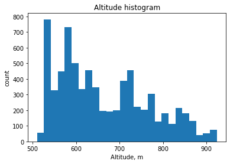

```python
plt.hist(road_ride.altitude, bins="fd")
plt.title("Altitude histogram")
plt.xlabel("Altitude, m")
plt.ylabel("count")
plt.show()
```

All entries contain altitude value. The sensor type is barometric. The resolution is 0.2m. Some noise is expected. Drift could also be expected in case of significant weather changes during the ride.

The main factor for changing gear is the slope of the terrain. It could be calculated from the altitude and the distance. The steeper the terrain, the lower gear ratio is preferred in order to keep the cadence near optimum value. The code below calculates the slope and adds it to the dataframe.

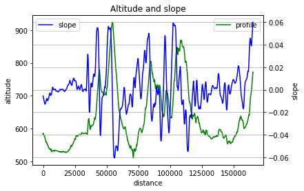

```python
def add_slope(df):
    """
    Adds a colum with the slope.
    First smoothening is performed
    """
    STEP = 10.0 # in m; the step through which smoothening will be done
    x = df.distance
    y = df.altitude
    f = interpolate.interp1d(x, y, fill_value="extrapolate")
    x2 = np.arange(x.min(), x.max(), STEP) # create steps every 10m; equal step is needed for the savgol_filter
    slope = savgol_filter(f(x2), window_length=201, polyorder=2, deriv=1, delta=STEP) # the data is noisy and requires smootheneing

    f_slope = interpolate.interp1d(x2, slope, fill_value="extrapolate")
    df["slope"] = f_slope(x)
    return df


road_ride = add_slope(road_ride)

sns.lineplot(x=road_ride.distance, y=road_ride.altitude, color="g", label="profile")
ax2 = plt.twinx()
sns.lineplot(x=road_ride.distance, y=road_ride.slope, color="b", ax=ax2, label="slope")
plt.title("Altitude and slope")
plt.xlabel("distance, m")
plt.legend()
plt.grid()
plt.show()
```

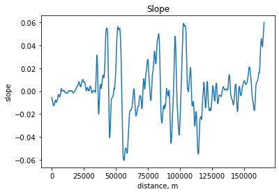

```python
plt.plot(road_ride.distance, road_ride.slope)
plt.title("Slope")
plt.xlabel("distance, m")
plt.ylabel("slope")
plt.show()
```

## Temperature

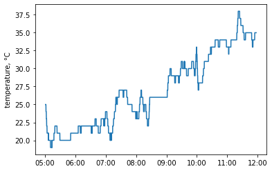

```python
plt.plot(road_ride.timestamp, road_ride.temperature)
xformatter = mdates.DateFormatter('%H:%M')
plt.gcf().axes[0].xaxis.set_major_formatter(xformatter)
plt.ylabel("temperature, °C")
plt.show()
```

Temperature increases towards lunch time. Nothing interesting.

## Generic correlations

```python
road_ride.corr()
```

|  | latitude | longitude | lap | altitude | heart_rate | cadence | speed | distance | temperature | duration | distance_increment | slope |
| --- | --- | --- | --- | --- | --- | --- | --- | --- | --- | --- | --- | --- |
| latitude | 1.000000 | -0.252159 | -0.349554 | -0.240271 | -0.170949 | 0.056960 | -0.096868 | -0.349526 | -0.344155 | 0.054398 | 0.001337 | 0.103798 |
| longitude | -0.252159 | 1.000000 | -0.386359 | 0.430231 | 0.052707 | -0.032547 | 0.143858 | -0.386896 | -0.480966 | -0.175363 | -0.091316 | -0.040817 |
| lap | -0.349554 | -0.386359 | 1.000000 | 0.103999 | 0.191407 | 0.019240 | -0.053433 | 0.999499 | 0.940115 | -0.015324 | -0.029440 | 0.063467 |
| altitude | -0.240271 | 0.430231 | 0.103999 | 1.000000 | 0.073259 | -0.145234 | -0.113611 | 0.105742 | -0.043856 | -0.218484 | -0.309159 | 0.136145 |
| heart_rate | -0.170949 | 0.052707 | 0.191407 | 0.073259 | 1.000000 | 0.554149 | -0.168701 | 0.187956 | 0.142025 | -0.020464 | 0.081450 | 0.626950 |
| cadence | 0.056960 | -0.032547 | 0.019240 | -0.145234 | 0.554149 | 1.000000 | 0.090090 | 0.016648 | 0.023753 | 0.092899 | 0.277922 | 0.325493 |
| speed | -0.096868 | 0.143858 | -0.053433 | -0.113611 | -0.168701 | 0.090090 | 1.000000 | -0.057670 | -0.058363 | -0.183991 | 0.464071 | -0.660780 |
| distance | -0.349526 | -0.386896 | 0.999499 | 0.105742 | 0.187956 | 0.016648 | -0.057670 | 1.000000 | 0.939755 | -0.013579 | -0.031951 | 0.063931 |
| temperature | -0.344155 | -0.480966 | 0.940115 | -0.043856 | 0.142025 | 0.023753 | -0.058363 | 0.939755 | 1.000000 | 0.013848 | 0.004042 | 0.051174 |
| duration | 0.054398 | -0.175363 | -0.015324 | -0.218484 | -0.020464 | 0.092899 | -0.183991 | -0.013579 | 0.013848 | 1.000000 | 0.583871 | 0.040695 |
| distance_increment | 0.001337 | -0.091316 | -0.029440 | -0.309159 | 0.081450 | 0.277922 | 0.464071 | -0.031951 | 0.004042 | 0.583871 | 1.000000 | -0.242511 |
| slope | 0.103798 | -0.040817 | 0.063467 | 0.136145 | 0.626950 | 0.325493 | -0.660780 | 0.063931 | 0.051174 | 0.040695 | -0.242511 | 1.000000 |

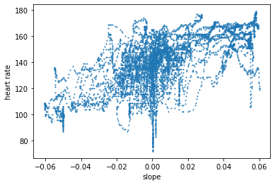

```python
plt.scatter(road_ride.slope, road_ride.heart_rate, s=1)
plt.xlabel("slope")
plt.ylabel("heart rate")
plt.show()
```

```python
# heart_rates = road_ride[np.isfinite(road_ride['heart_rate'])].heart_rate
# slopes = road_ride[np.isfinite(road_ride['heart_rate'])].slope
# plt.hist2d(slopes, heart_rates, bins=100, cmap=plt.cm.jet, cmin=1, cmax=10)
# plt.xlabel("slope")
# plt.ylabel("heart rate")
# plt.show()
```

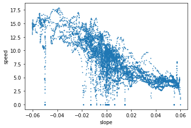

```python
plt.scatter(road_ride.slope, road_ride.speed, s=1)
plt.xlabel("slope")
plt.ylabel("speed")
plt.show()
```

```python
# speeds = road_ride.speed
# slopes = road_ride.slope
# plt.hist2d(slopes, speeds, bins=100, cmap=plt.cm.jet, cmin=1, cmax=10)
# plt.xlabel("slope")
# plt.ylabel("speed")
# plt.show()
```

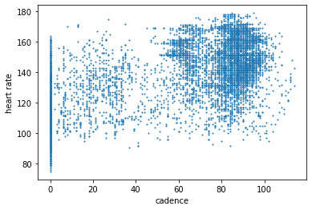

```python
# some correlation between heart rate and cadance is seen;
plt.scatter(road_ride.cadence, road_ride.heart_rate, s=1)
plt.xlabel("cadence")
plt.ylabel("heart rate")
plt.show()
```

Later more columns will be derived, and correlations will be explored.

# Analysis of current gear ratio usage of the 2x11 setup

## Calculating the gear ratios

By definition, the gear ratio is the ratio between the number of teeth on the chainring divided by the number of teeth on the selected rear cog. The gear ratio can be calculated from the speed and cadence.

```python
def add_gear_ratios(df):
    gear_ratios = (df.speed / TYRE_CIRCUMFERENCE) / (df.cadence / 60) # dimensionless; number of chainring theeth divided by the cog theeth
    gear_ratios.name = "gear_ratio"
    df = pd.concat([df, gear_ratios], axis=1)
    return df

road_ride = add_gear_ratios(road_ride)
```

```python
road_ride.gear_ratio.min(), road_ride.gear_ratio.max()
```

```
(0.0, inf)
```

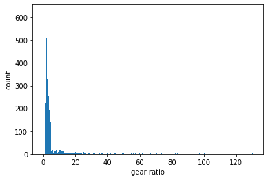

```python
plt.hist(road_ride.gear_ratio[road_ride.gear_ratio < 200], bins="fd")
# plt.ylim(0,10)
plt.xlabel("gear ratio")
plt.ylabel("count")
plt.show()
```

```python
road_ride.gear_ratio[road_ride.gear_ratio > 20].count()
```

```
984
```

There is an issue with such direct approach: dividing by 0 cadence results in infinity. When the bike is moved by inertia, the formula indicates infinite gear ratio; but in reality, in this case the gear ratio cannot be determined (any gear could be engaged when freewheeling). Not knowing the gear ratio when freewheeling is not a big concern as the rider is simply not turning the cranks.

What is the best usage metric. Here are some proposals with comments:

- number of records in the dataframe - not good (even wrong) as the duration differs
- number of kilometers at a given gear ratio - would indicate high usage of fast gears; good resolution could be obtained.
- number of crank turns at a given gear ratio - assuming a constant power per rotation coming from the rider, would indicate the total energy used at a give ratio. However the resolution would be quite poor as the resolution of cadence and duration for each record is low.
- number of hours at a given gear ratio - if the power input from the rider is constant, this would also be indication for the total amount of energy spent at a give gear ratio.
- number of chain engagement/disengagement in the cogs - good indicator for wear, but difficult to calculate, because:
  - two chainrings are possible
  - depends on overlap angle
  - depends on cog material (Steel, Ti or Al)
  - depends on chainline diagonal

The analysis will continue with a usage metric in the distance and time domain.

The highest possible gear ratio of the current setup can be calculated by dividing the teeth of the largest chainring to the teeth of the smallest cog. If we exclude any gear ratio higher than that, we will exclude the freewheeling.

```python
slow_gears = {} # used by 34t chainring
fast_gears = {} # used by 50t chainring
for cog in COGS[::-1]:
    slow_gears[f"{CHAINRINGS[0]}/{cog}"] = CHAINRINGS[0] / cog
    fast_gears[f"{CHAINRINGS[1]}/{cog}"] = CHAINRINGS[1] / cog
lowest_gear = min(slow_gears.values())
highest_gear = max(fast_gears.values())
lowest_gear, highest_gear
```

```
(1.2142857142857142, 4.545454545454546)
```

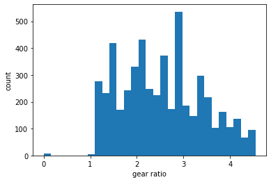

```python
plt.hist(road_ride.gear_ratio[road_ride.gear_ratio <= highest_gear], bins="fd")
plt.xlabel("gear ratio")
plt.ylabel("count")
plt.show()
```

```python
road_ride[pd.isna(road_ride.gear_ratio)]
```

|  | latitude | longitude | lap | altitude | timestamp | heart_rate | cadence | speed | distance | temperature | duration | distance_increment | slope | gear_ratio |
| --- | --- | --- | --- | --- | --- | --- | --- | --- | --- | --- | --- | --- | --- | --- |
| 108 | 42.682622 | 23.320529 | 1 | 557.2 | 2021-06-27 05:05:39+00:00 | 111.0 | 0.0 | 0.0 | 2705.98 | 21 | 1.0 | 0.00 | -0.008182 | NaN |
| 110 | 42.682629 | 23.320544 | 1 | 556.8 | 2021-06-27 05:05:44+00:00 | 111.0 | 0.0 | 0.0 | 2707.60 | 21 | 3.0 | 0.00 | -0.008177 | NaN |
| 111 | 42.682629 | 23.320544 | 1 | 556.6 | 2021-06-27 05:05:45+00:00 | 112.0 | 0.0 | 0.0 | 2707.60 | 21 | 1.0 | 0.00 | -0.008177 | NaN |
| 259 | 42.696733 | 23.354435 | 2 | 537.0 | 2021-06-27 05:12:34+00:00 | 115.0 | 0.0 | 0.0 | 6054.83 | 19 | 5.0 | 1.53 | -0.005036 | NaN |
| 260 | 42.696733 | 23.354435 | 2 | 537.2 | 2021-06-27 05:12:38+00:00 | 112.0 | 0.0 | 0.0 | 6054.83 | 19 | 4.0 | 0.00 | -0.005036 | NaN |
| ... | ... | ... | ... | ... | ... | ... | ... | ... | ... | ... | ... | ... | ... | ... |
| 6645 | 42.708705 | 23.251921 | 31 | 590.6 | 2021-06-27 11:21:36+00:00 | 124.0 | 0.0 | 0.0 | 153144.90 | 37 | 7.0 | 0.00 | 0.014746 | NaN |
| 6646 | 42.708705 | 23.251921 | 31 | 590.6 | 2021-06-27 11:21:39+00:00 | 121.0 | 0.0 | 0.0 | 153144.90 | 37 | 3.0 | 0.00 | 0.014746 | NaN |
| 6647 | 42.708705 | 23.251921 | 31 | 590.8 | 2021-06-27 11:21:43+00:00 | 119.0 | 0.0 | 0.0 | 153144.90 | 37 | 4.0 | 0.00 | 0.014746 | NaN |
| 6648 | 42.708711 | 23.251916 | 31 | 590.8 | 2021-06-27 11:21:50+00:00 | 115.0 | 0.0 | 0.0 | 153145.30 | 38 | 7.0 | 0.40 | 0.014750 | NaN |
| 7266 | 42.685618 | 23.139071 | 34 | 771.8 | 2021-06-27 11:57:26+00:00 | 120.0 | 0.0 | 0.0 | 165349.71 | 35 | 5.0 | 0.00 | 0.060010 | NaN |

333 rows × 14 columns

```python
road_ride[road_ride.gear_ratio == 0.0]
```

|  | latitude | longitude | lap | altitude | timestamp | heart_rate | cadence | speed | distance | temperature | duration | distance_increment | slope | gear_ratio |
| --- | --- | --- | --- | --- | --- | --- | --- | --- | --- | --- | --- | --- | --- | --- |
| 1956 | 42.717119 | 23.874636 | 11 | 769.8 | 2021-06-27 06:57:49+00:00 | 156.0 | 15.0 | 0.0 | 51265.87 | 22 | 5.0 | 0.00 | 0.054944 | 0.0 |
| 1957 | 42.717119 | 23.874636 | 11 | 770.0 | 2021-06-27 06:57:51+00:00 | 155.0 | 15.0 | 0.0 | 51265.87 | 22 | 2.0 | 0.00 | 0.054944 | 0.0 |
| 2465 | 42.702785 | 23.925150 | 12 | 777.4 | 2021-06-27 07:14:36+00:00 | 98.0 | 7.0 | 0.0 | 57369.28 | 22 | 3.0 | 0.00 | -0.050251 | 0.0 |
| 2468 | 42.702764 | 23.925129 | 12 | 777.4 | 2021-06-27 07:14:42+00:00 | 103.0 | 7.0 | 0.0 | 57370.51 | 22 | 2.0 | 0.00 | -0.050246 | 0.0 |
| 3921 | 42.655976 | 23.821507 | 18 | 728.4 | 2021-06-27 08:27:39+00:00 | 138.0 | 59.0 | 0.0 | 89611.47 | 26 | 1.0 | 0.00 | 0.001537 | 0.0 |
| 6611 | 42.708705 | 23.251921 | 31 | 592.2 | 2021-06-27 11:18:34+00:00 | 143.0 | 4.0 | 0.0 | 153144.90 | 34 | 7.0 | 2.13 | 0.014746 | 0.0 |
| 7265 | 42.685618 | 23.139071 | 34 | 771.8 | 2021-06-27 11:57:21+00:00 | 119.0 | 4.0 | 0.0 | 165349.71 | 35 | 4.0 | 0.00 | 0.060010 | 0.0 |

```python
road_ride[2460:2470] # taking a closer look
```

|  | latitude | longitude | lap | altitude | timestamp | heart_rate | cadence | speed | distance | temperature | duration | distance_increment | slope | gear_ratio |
| --- | --- | --- | --- | --- | --- | --- | --- | --- | --- | --- | --- | --- | --- | --- |
| 2465 | 42.702785 | 23.925150 | 12 | 777.4 | 2021-06-27 07:14:36+00:00 | 98.0 | 7.0 | 0.000 | 57369.28 | 22 | 3.0 | 0.00 | -0.050251 | 0.000000 |
| 2466 | 42.702775 | 23.925141 | 12 | 777.4 | 2021-06-27 07:14:39+00:00 | 101.0 | 7.0 | 0.411 | 57370.10 | 22 | 3.0 | 0.82 | -0.050248 | 1.673566 |
| 2467 | 42.702765 | 23.925132 | 12 | 777.4 | 2021-06-27 07:14:40+00:00 | 102.0 | 7.0 | 0.411 | 57370.51 | 22 | 1.0 | 0.41 | -0.050246 | 1.673566 |
| 2468 | 42.702764 | 23.925129 | 12 | 777.4 | 2021-06-27 07:14:42+00:00 | 103.0 | 7.0 | 0.000 | 57370.51 | 22 | 2.0 | 0.00 | -0.050246 | 0.000000 |
| 2469 | 42.702764 | 23.925129 | 12 | 777.6 | 2021-06-27 07:14:47+00:00 | 100.0 | 0.0 | 0.000 | 57370.51 | 22 | 5.0 | 0.00 | -0.050246 | NaN |
| 2470 | 42.702764 | 23.925129 | 12 | 777.4 | 2021-06-27 07:14:50+00:00 | 102.0 | 0.0 | 0.000 | 57370.51 | 22 | 3.0 | 0.00 | -0.050246 | NaN |
| 2471 | 42.702764 | 23.925129 | 12 | 777.2 | 2021-06-27 07:15:16+00:00 | 98.0 | 0.0 | 0.000 | 57370.51 | 23 | 26.0 | 0.00 | -0.050246 | NaN |
| 2472 | 42.702764 | 23.925129 | 12 | 777.0 | 2021-06-27 07:15:19+00:00 | 95.0 | 0.0 | 0.000 | 57370.51 | 23 | 3.0 | 0.00 | -0.050246 | NaN |
| 2473 | 42.702764 | 23.925129 | 12 | 777.0 | 2021-06-27 07:15:25+00:00 | 95.0 | 0.0 | 0.000 | 57370.51 | 23 | 6.0 | 0.00 | -0.050246 | NaN |
| 2474 | 42.702764 | 23.925129 | 12 | 777.0 | 2021-06-27 07:15:30+00:00 | 92.0 | 0.0 | 0.000 | 57370.51 | 23 | 5.0 | 0.00 | -0.050246 | NaN |

A couple of gear ratios are equal to 0, due to speed equal to 0 and some, non-zero, cadence. The data indicates this happens during transition periods to stop. It could also happen if the rider is back pedaling.

```python
road_ride[road_ride.gear_ratio < lowest_gear]
```

|  | latitude | longitude | lap | altitude | timestamp | heart_rate | cadence | speed | distance | temperature | duration | distance_increment | slope | gear_ratio |
| --- | --- | --- | --- | --- | --- | --- | --- | --- | --- | --- | --- | --- | --- | --- |
| 1953 | 42.717113 | 23.874516 | 11 | 768.4 | 2021-06-27 06:57:39+00:00 | 163.0 | 71.0 | 2.939 | 51255.97 | 22 | 1.0 | 2.94 | 0.054790 | 1.179887 |
| 1954 | 42.717120 | 23.874561 | 11 | 768.4 | 2021-06-27 06:57:40+00:00 | 163.0 | 71.0 | 2.557 | 51258.52 | 22 | 1.0 | 2.55 | 0.054830 | 1.026530 |
| 1956 | 42.717119 | 23.874636 | 11 | 769.8 | 2021-06-27 06:57:49+00:00 | 156.0 | 15.0 | 0.000 | 51265.87 | 22 | 5.0 | 0.00 | 0.054944 | 0.000000 |
| 1957 | 42.717119 | 23.874636 | 11 | 770.0 | 2021-06-27 06:57:51+00:00 | 155.0 | 15.0 | 0.000 | 51265.87 | 22 | 2.0 | 0.00 | 0.054944 | 0.000000 |
| 2465 | 42.702785 | 23.925150 | 12 | 777.4 | 2021-06-27 07:14:36+00:00 | 98.0 | 7.0 | 0.000 | 57369.28 | 22 | 3.0 | 0.00 | -0.050251 | 0.000000 |
| ... | ... | ... | ... | ... | ... | ... | ... | ... | ... | ... | ... | ... | ... | ... |
| 7253 | 42.686017 | 23.138795 | 34 | 769.0 | 2021-06-27 11:56:47+00:00 | 136.0 | 66.0 | 2.734 | 165282.68 | 35 | 5.0 | 14.32 | 0.058742 | 1.180739 |
| 7254 | 42.685978 | 23.138758 | 34 | 769.6 | 2021-06-27 11:56:49+00:00 | 136.0 | 63.0 | 2.491 | 165287.86 | 35 | 2.0 | 5.18 | 0.058840 | 1.127022 |
| 7256 | 42.685882 | 23.138714 | 34 | 770.4 | 2021-06-27 11:56:54+00:00 | 136.0 | 52.0 | 2.025 | 165298.96 | 35 | 2.0 | 4.24 | 0.059050 | 1.109995 |
| 7258 | 42.685803 | 23.138667 | 34 | 771.4 | 2021-06-27 11:56:59+00:00 | 135.0 | 53.0 | 1.997 | 165309.97 | 35 | 1.0 | 2.00 | 0.059258 | 1.073993 |
| 7265 | 42.685618 | 23.139071 | 34 | 771.8 | 2021-06-27 11:57:21+00:00 | 119.0 | 4.0 | 0.000 | 165349.71 | 35 | 4.0 | 0.00 | 0.060010 | 0.000000 |

176 rows × 14 columns

```python
road_ride[1950:1965] # takin a close look
```

|  | latitude | longitude | lap | altitude | timestamp | heart_rate | cadence | speed | distance | temperature | duration | distance_increment | slope | gear_ratio |
| --- | --- | --- | --- | --- | --- | --- | --- | --- | --- | --- | --- | --- | --- | --- |
| 1954 | 42.717120 | 23.874561 | 11 | 768.4 | 2021-06-27 06:57:40+00:00 | 163.0 | 71.0 | 2.557 | 51258.52 | 22 | 1.0 | 2.55 | 0.054830 | 1.026530 |
| 1955 | 42.717119 | 23.874631 | 11 | 769.4 | 2021-06-27 06:57:44+00:00 | 159.0 | 17.0 | 1.409 | 51265.87 | 22 | 4.0 | 7.35 | 0.054944 | 2.362442 |
| 1956 | 42.717119 | 23.874636 | 11 | 769.8 | 2021-06-27 06:57:49+00:00 | 156.0 | 15.0 | 0.000 | 51265.87 | 22 | 5.0 | 0.00 | 0.054944 | 0.000000 |
| 1957 | 42.717119 | 23.874636 | 11 | 770.0 | 2021-06-27 06:57:51+00:00 | 155.0 | 15.0 | 0.000 | 51265.87 | 22 | 2.0 | 0.00 | 0.054944 | 0.000000 |
| 1958 | 42.717119 | 23.874636 | 11 | 769.8 | 2021-06-27 06:57:54+00:00 | 152.0 | 0.0 | 0.000 | 51265.87 | 22 | 3.0 | 0.00 | 0.054944 | NaN |
| 1959 | 42.717119 | 23.874636 | 11 | 769.8 | 2021-06-27 06:58:00+00:00 | 149.0 | 0.0 | 0.000 | 51265.87 | 23 | 6.0 | 0.00 | 0.054944 | NaN |
| 1960 | 42.717119 | 23.874636 | 11 | 769.8 | 2021-06-27 06:58:04+00:00 | 146.0 | 0.0 | 0.000 | 51265.87 | 23 | 4.0 | 0.00 | 0.054944 | NaN |
| 1961 | 42.717119 | 23.874636 | 11 | 769.8 | 2021-06-27 06:58:07+00:00 | 143.0 | 0.0 | 0.000 | 51265.87 | 23 | 3.0 | 0.00 | 0.054944 | NaN |
| 1962 | 42.717119 | 23.874636 | 11 | 769.8 | 2021-06-27 06:58:10+00:00 | 140.0 | 0.0 | 0.000 | 51265.87 | 23 | 3.0 | 0.00 | 0.054944 | NaN |
| 1963 | 42.717119 | 23.874636 | 11 | 769.8 | 2021-06-27 06:58:13+00:00 | 137.0 | 0.0 | 0.000 | 51265.87 | 23 | 3.0 | 0.00 | 0.054944 | NaN |
| 1964 | 42.717119 | 23.874636 | 11 | 769.6 | 2021-06-27 06:58:16+00:00 | 134.0 | 0.0 | 0.000 | 51265.87 | 23 | 3.0 | 0.00 | 0.054944 | NaN |
| 1965 | 42.717119 | 23.874636 | 11 | 769.6 | 2021-06-27 06:58:19+00:00 | 131.0 | 0.0 | 0.000 | 51265.87 | 23 | 3.0 | 0.00 | 0.054944 | NaN |
| 1966 | 42.717119 | 23.874636 | 11 | 769.6 | 2021-06-27 06:58:22+00:00 | 128.0 | 0.0 | 0.000 | 51265.87 | 23 | 3.0 | 0.00 | 0.054944 | NaN |
| 1967 | 42.717119 | 23.874636 | 11 | 769.6 | 2021-06-27 06:58:24+00:00 | 124.0 | 0.0 | 0.000 | 51265.87 | 23 | 2.0 | 0.00 | 0.054944 | NaN |
| 1968 | 42.717119 | 23.874636 | 11 | 769.6 | 2021-06-27 06:58:27+00:00 | 121.0 | 0.0 | 0.000 | 51265.87 | 23 | 3.0 | 0.00 | 0.054944 | NaN |

```python
# road_ride[7240:7265] # another closer look
```

Again, gear ratio out of range is happening during acceleration and stopping.

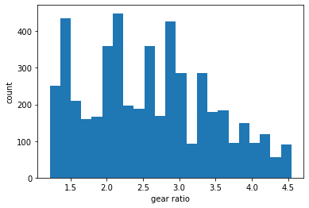

```python
plt.hist(road_ride.gear_ratio[(road_ride.gear_ratio <= highest_gear) & (road_ride.gear_ratio >= lowest_gear)], bins="fd")
plt.xlabel("gear ratio")
plt.ylabel("count")
plt.show()
```

## EDA of currently used gear ratios

Currently, there are pre-defined gear-ratios. It might be possible to see indication for data discretization. The code below tries to find and evaluate the used gears from the 2x11 drive-train.

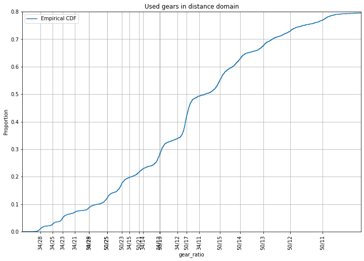

```python
plt.figure(figsize=(12,8))
sns.ecdfplot(data=road_ride, x="gear_ratio", label=f"Empirical CDF", weights=road_ride.distance_increment)

plt.xticks(list(slow_gears.values()) + list(fast_gears.values()),
           list(slow_gears.keys()) + list(fast_gears.keys()),
           rotation=90)

# plt.hlines(0.022, 1,2)
plt.title("Used gears in distance domain")
plt.xlim(1, 5)
plt.ylim(0, 0.8)
plt.legend()
plt.grid()
plt.show()
```

The Empirical CDF plot clearly shows the used gears from the current setup. There is "normal" distribution around each gear. One can see the steep sectionс crossing the pre-defined gear ratios. There is noise that creates the tails. If there was no noise, the ECDF plot would look like staircase: vertical sections at the gear ratios, and a horizontal step to the next gear.

50/17 is the most used gear in terms of distance. The gears at both ends of the available ratios are less used (expected)

The rider should avoid diagonal chainlines (like 34/11), but data indicates significant usage of 50/23. It is recommended to use either 34/17 or 34/15.

About 20% of the distance the rider is freewheeling.

The following code calculates the most likely gear engaged for each row in the dataframe. Applied rules for data discretization:

- The nearest gear ratio will be selected
- the range for border gears will be symmetrical about the nominal
- gear ratios higher than the fastest bin will be classified as freewheeling
- for moderate gear ratios, the most proper gear will be selected by avoiding crossed chain.
- the slowest gear to use the big chainring will be assumed 50/21

```python
def calculate_suitable_gear_2_11(ratio) -> str:
    """
    returns the most proper gear combo

    """
    if ratio == 0 or pd.isna(ratio):
        return "stationary"
    if ratio > fast_gears["50/11"] + 0.5 * (fast_gears["50/11"] - fast_gears["50/12"]):
        return "freewheeling"
    if ratio < 0.5 * (fast_gears["50/21"] + slow_gears["34/15"]):
        front_teeth = CHAINRINGS.min()
    else:
        front_teeth = CHAINRINGS.max()
    diffrence_to_possible_ratios = np.abs(front_teeth / COGS - ratio)
    cog_index = diffrence_to_possible_ratios.argmin()
    rear_teeth = COGS[cog_index]
    return f"{front_teeth}/{rear_teeth}"


#unit test of the dunction
assert(calculate_suitable_gear_2_11(np.nan) == 'stationary')
assert(calculate_suitable_gear_2_11(np.inf) == 'freewheeling')
x = np.linspace(0, 5, 40)
calculate_suitable_gear_2_11_v = np.vectorize(calculate_suitable_gear_2_11)
expected_result = ['stationary', '34/28', '34/28', '34/28', '34/28', '34/28', '34/28',
       '34/28', '34/28', '34/28', '34/28', '34/25', '34/23', '34/21',
       '34/19', '34/17', '34/17', '34/15', '34/15', '50/21', '50/19',
       '50/19', '50/17', '50/17', '50/17', '50/15', '50/15', '50/14',
       '50/14', '50/13', '50/13', '50/13', '50/12', '50/12', '50/11',
       '50/11', '50/11', 'freewheeling', 'freewheeling', 'freewheeling']
assert((calculate_suitable_gear_2_11_v(x) == expected_result).all())
```

```python
def add_gears(df):
    """
    adds a colum with the most proper gear for a 2x11 setup.
    the column is ordered categorical
    """
    df["gear"] = df.gear_ratio.apply(calculate_suitable_gear_2_11)
    used_gears = df["gear"].unique()
    all_gears = ['stationary',
                '34/28','34/25','34/23','34/21','34/19','34/17','34/15',
                '50/21', '50/19','50/17','50/15','50/14','50/13','50/12','50/11',
                'freewheeling']
    ordered_gears = [el for el in all_gears if el in used_gears]
    df.gear = pd.Categorical(df.gear, ordered=True, categories = ordered_gears)
    return df


road_ride = add_gears(road_ride)

assert (len(road_ride[pd.isna(road_ride.gear)]) == 0)
assert (road_ride.gear.min() == 'stationary')
assert (road_ride.gear.max() == 'freewheeling')
```

```python
# creating a dataframe with usage of the gear system
powered_data = road_ride[~road_ride.gear.isin(['stationary', 'freewheeling'])]
```

```python
powered_data.corr().round(2)
```

|  | latitude | longitude | lap | altitude | heart_rate | cadence | speed | distance | temperature | duration | distance_increment | slope | gear_ratio |
| --- | --- | --- | --- | --- | --- | --- | --- | --- | --- | --- | --- | --- | --- |
| latitude | 1.00 | -0.25 | -0.33 | -0.16 | -0.28 | -0.09 | -0.03 | -0.32 | -0.32 | 0.01 | 0.02 | 0.07 | 0.01 |
| longitude | -0.25 | 1.00 | -0.46 | 0.38 | 0.19 | 0.03 | -0.01 | -0.46 | -0.55 | -0.17 | -0.15 | 0.12 | -0.03 |
| lap | -0.33 | -0.46 | 1.00 | 0.07 | 0.12 | -0.02 | -0.13 | 1.00 | 0.95 | 0.03 | -0.07 | 0.04 | -0.14 |
| altitude | -0.16 | 0.38 | 0.07 | 1.00 | 0.23 | -0.16 | -0.36 | 0.07 | -0.07 | -0.25 | -0.40 | 0.41 | -0.36 |
| heart_rate | -0.28 | 0.19 | 0.12 | 0.23 | 1.00 | 0.08 | -0.44 | 0.12 | 0.05 | 0.03 | -0.15 | 0.59 | -0.54 |
| cadence | -0.09 | 0.03 | -0.02 | -0.16 | 0.08 | 1.00 | 0.50 | -0.02 | -0.03 | 0.14 | 0.33 | -0.29 | 0.14 |
| speed | -0.03 | -0.01 | -0.13 | -0.36 | -0.44 | 0.50 | 1.00 | -0.13 | -0.09 | 0.05 | 0.48 | -0.82 | 0.92 |
| distance | -0.32 | -0.46 | 1.00 | 0.07 | 0.12 | -0.02 | -0.13 | 1.00 | 0.95 | 0.03 | -0.07 | 0.04 | -0.14 |
| temperature | -0.32 | -0.55 | 0.95 | -0.07 | 0.05 | -0.03 | -0.09 | 0.95 | 1.00 | 0.05 | -0.02 | -0.01 | -0.09 |
| duration | 0.01 | -0.17 | 0.03 | -0.25 | 0.03 | 0.14 | 0.05 | 0.03 | 0.05 | 1.00 | 0.85 | -0.07 | 0.01 |
| distance_increment | 0.02 | -0.15 | -0.07 | -0.40 | -0.15 | 0.33 | 0.48 | -0.07 | -0.02 | 0.85 | 1.00 | -0.42 | 0.42 |
| slope | 0.07 | 0.12 | 0.04 | 0.41 | 0.59 | -0.29 | -0.82 | 0.04 | -0.01 | -0.07 | -0.42 | 1.00 | -0.82 |
| gear_ratio | 0.01 | -0.03 | -0.14 | -0.36 | -0.54 | 0.14 | 0.92 | -0.14 | -0.09 | 0.01 | 0.42 | -0.82 | 1.00 |

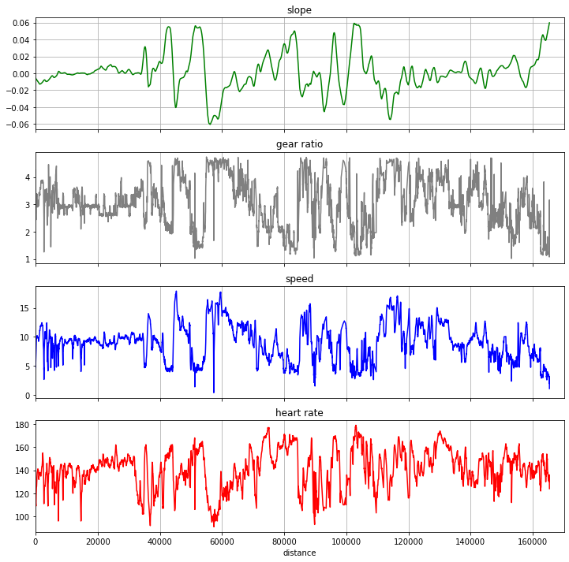

```python
f, (ax1, ax2, ax3, ax4) = plt.subplots(4, 1, sharex='col', figsize=(12,12))
ax1.plot(powered_data.distance, powered_data.slope, color="green", label="slope")
ax2.plot(powered_data.distance, powered_data.gear_ratio, color="gray", label="gear ratio")
ax3.plot(powered_data.distance, powered_data.speed, color="blue", label="speed")
ax4.plot(powered_data.distance, powered_data.heart_rate, color="red", label="heart rate")
ax1.title.set_text("slope")
ax2.title.set_text("gear ratio")
ax3.title.set_text("speed")
ax4.title.set_text("heart rate")
ax1.grid()
ax2.grid(axis="x")
ax3.grid(axis="x")
ax4.grid(axis="x")
ax4.set_xlabel('distance')
plt.xlim(0, 170000)
plt.show()
```

As expected, there is strong correlation between slope, gear ratio and speed (and to some degree heart rate). The main factor for changing a gear is change in slope. The gear ratio graph has some noise, but overall it is continues. The heart rate has some delay and also depends on the effort of the rider.

There are several significant correlations between slope, gear ratio, speed and cadence. The speed is a linear function of cadence and gear ratio, so the independent variables are 3 - slope, gear ratio and speed. The cadence has lower correlation probably because of noise in the data. The code below tries to visualize them.

```python
def plot_three_columns(df, y_str, z_str):
    """function to plot three columns
    x = gear ratio
    y and z can be selected
    z is plotted with color bar
    """
    x = df["gear_ratio"]
    y = df[y_str]
    z = df[z_str] # cadence and slope is also intresting

    f, ax = plt.subplots(figsize=(12,8))
    points = ax.scatter(x, y, c=z, s=1, cmap="turbo") #cmap="turbo"
    cbar = f.colorbar(points)
    cbar.set_label(z_str)

    plt.xticks(list(slow_gears.values()) + list(fast_gears.values()),
               list(slow_gears.keys()) + list(fast_gears.keys()),
               rotation=90)
    plt.xlabel("gear_ratio")
    plt.ylabel(y_str)
    plt.grid()
    plt.xlim(1, 5)
#     plt.show()
    return ax
```

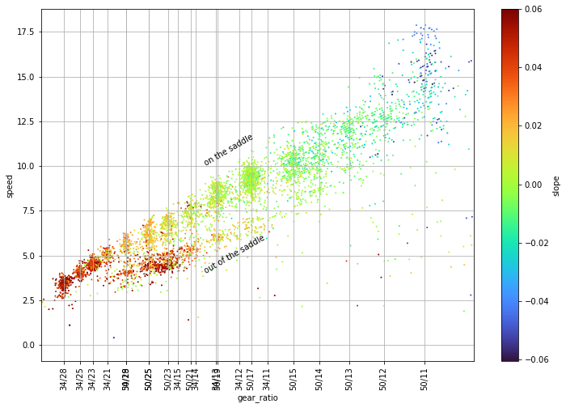

```python
ax = plot_three_columns(road_ride, "speed", "slope")
ax.text(2.5, 4, "out of the saddle", rotation=30)
ax.text(2.5, 10, "on the saddle", rotation=30)
plt.show()
```

Observations from the graph above :

- the steeper the terrain the slower the speed
- data clustered around the fixed gear ratios
- There is good overlap in speed - the rider can choose between a couple of gears for a given speed
- there are two linear regressions, the slope of which is defined by two different typical cadences. The higher cadence is used for on the saddle efforts and the lower cadence is used for out of the saddle efforts.
- The above observation is also confirmed by the slope. Notice that in the interval 4 to 6% uphill there are two distinguished red zones. The left is on the saddle and the right is out of the saddle.
- the top speed is achieved at 50/11 gear. One could notice these data points do not fit the linear regression. The reason is that the rider does not have higher gear and is forced to increase the cadence to keep up with the group. **There is motivation to add a faster gear in the new 1x12 setup.**

The graph below shows the high cadence at the top gear. The iso-color data points actually define a fixed cadence.

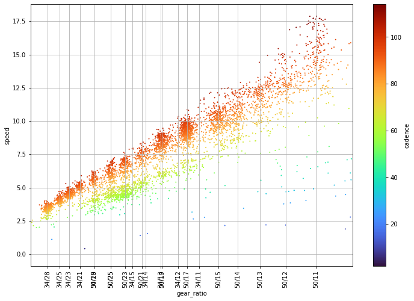

```python
plot_three_columns(road_ride, "speed", "cadence")
plt.show()
```

The cadence is expected to have bi-normal distribution:

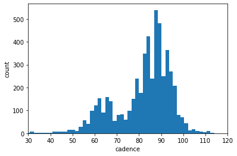

```python
plt.hist(powered_data.cadence, bins="fd")
plt.xlabel("cadence")
plt.ylabel("count")
plt.xlim(30, 120)
plt.show()
```

The graphs below demonstrate the heart rate and indirectly the power usage.

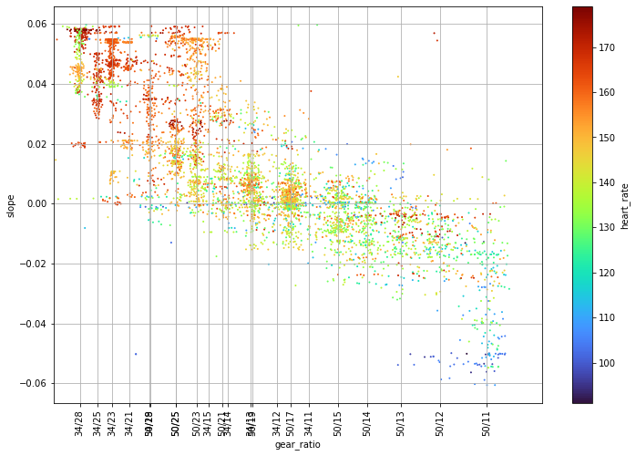

```python
plot_three_columns(powered_data, "slope", "heart_rate") #[powered_data.heart_rate > 160]
plt.show()
```

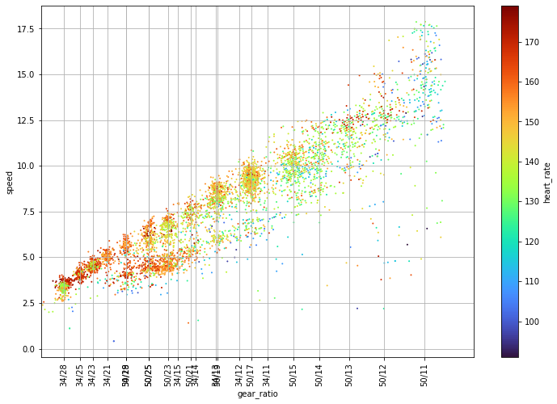

```python
plot_three_columns(powered_data, "speed", "heart_rate")
plt.show()
```

Looking at the heart rate, one can observe the steep climbs are more power demanding than fast sprints.

The lowest gear has significant amount of records with lowish heart rates - it is considered that these records represent resting of the rider by shifting down. The lowest gear has significant amount of records with very high heart rate - a sign that lower gear might be beneficial. **There is motivation to add a slower gear in the new 1x12 setup.**

The 34/25 gear should be used more instead of 34/23.

## Statistics by gear

```python
gear_stats_means = road_ride.groupby("gear").mean()[["speed", "gear_ratio", "cadence", "heart_rate", "slope"]]
gear_stats_sums = road_ride.groupby("gear").sum()[["distance_increment", "duration"]]
gear_stats = pd.concat([gear_stats_means, gear_stats_sums], axis=1)
gear_stats.columns = ["mean_speed", "mean_gear_ratio", "mean_cadence", "mean_heart_rate", "mean_slope", "distance", "duration"]
gear_stats.round(2)
```

| gear | mean_speed | mean_gear_ratio | mean_cadence | mean_heart_rate | mean_slope | distance | duration |
| --- | --- | --- | --- | --- | --- | --- | --- |
| stationary | 0.02 | 0.00 | 0.37 | 102.32 | -0.00 | 28.42 | 2056.0 |
| 34/28 | 3.37 | 1.21 | 79.30 | 157.32 | 0.05 | 3365.40 | 992.0 |
| 34/25 | 4.06 | 1.36 | 85.15 | 163.53 | 0.04 | 2524.34 | 619.0 |
| 34/23 | 4.49 | 1.48 | 86.48 | 158.83 | 0.04 | 4589.02 | 1023.0 |
| 34/21 | 4.80 | 1.62 | 84.69 | 156.32 | 0.03 | 2099.07 | 434.0 |
| 34/19 | 4.78 | 1.80 | 75.97 | 153.51 | 0.03 | 3822.84 | 782.0 |
| 34/17 | 5.32 | 2.02 | 75.07 | 153.69 | 0.03 | 8814.74 | 1592.0 |
| 34/15 | 5.68 | 2.20 | 73.66 | 150.42 | 0.02 | 8245.37 | 1397.0 |
| 50/21 | 6.52 | 2.40 | 77.42 | 147.26 | 0.01 | 5745.75 | 855.0 |
| 50/19 | 7.86 | 2.63 | 85.09 | 143.50 | 0.01 | 15423.59 | 1922.0 |
| 50/17 | 8.88 | 2.94 | 85.97 | 141.60 | 0.00 | 27111.85 | 3020.0 |
| 50/15 | 9.77 | 3.32 | 83.86 | 137.57 | -0.00 | 16058.91 | 1658.0 |
| 50/14 | 10.35 | 3.57 | 82.74 | 135.88 | -0.01 | 9693.34 | 953.0 |
| 50/13 | 11.40 | 3.86 | 84.13 | 139.97 | -0.01 | 8838.20 | 777.0 |
| 50/12 | 12.23 | 4.17 | 83.56 | 137.63 | -0.01 | 7455.83 | 612.0 |
| 50/11 | 14.07 | 4.55 | 88.15 | 125.44 | -0.03 | 6172.86 | 454.0 |
| freewheeling | 9.97 | inf | 13.64 | 124.12 | -0.02 | 34426.34 | 3720.0 |

```python
assert(abs(gear_stats.distance.sum() - road_ride.distance.tail(1).sum())) < 1000
```

```python
gear_stats = gear_stats.drop(["stationary"])
```

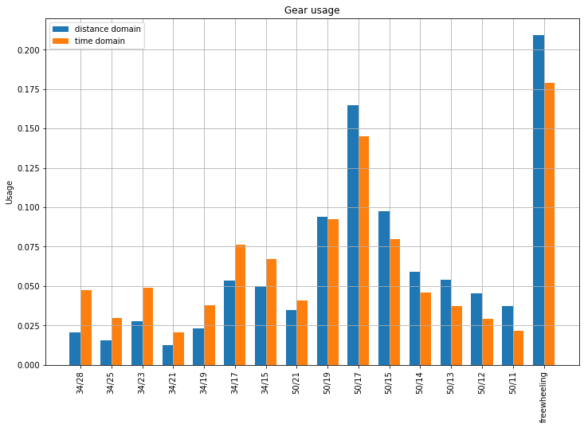

```python
def plot_gear_usage(df):
    bar_width = 0.35
    x = np.arange(len(df))
    fig, ax = plt.subplots(figsize=(12,8))
    distance = ax.bar(x, df.distance/df.distance.sum(), bar_width, label="distance domain")
    time = ax.bar(x+bar_width, df.duration/df.duration.sum(), bar_width, label="time domain")

    ax.set_title('Gear usage')
    ax.set_xticks(x + bar_width / 2)
    ax.set_xticklabels(df.index)
    plt.ylabel("Usage")
    ax.legend()
    plt.xticks(rotation=90)
    plt.grid()
    plt.show()


plot_gear_usage(gear_stats)
```

As expected, at lower gears the usage in time domain is higher than the usage in the distance domain. For high gears, the opposite is valid.

There is significant variation in the usage of gears. 50/17 the most used gear in terms of distance and time.

The time domain is considered more representative for the needs of the rider. In the time domain, the usage of the top gear is about 2 times less than the slowest gear.

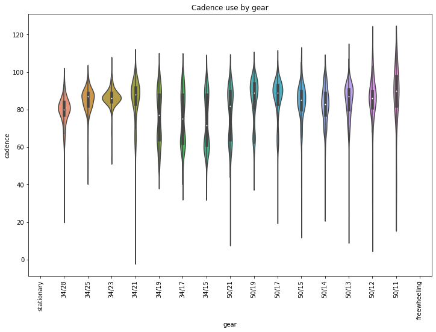

```python
fig, ax = plt.subplots(figsize=(12, 8))
sns.violinplot(ax=ax, data=powered_data, x="gear", y="cadence")
plt.title("Cadence use by gear")
plt.xticks(rotation=90)
plt.show()
```

The mid gears have wider, bi-modal distribution. It is due to the fact that these gears are used both on and out of the saddle. The slowest gear has lowish cadence, while the top gear has highish cadence.

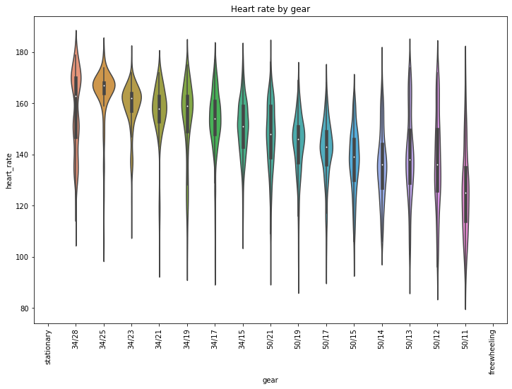

```python
fig, ax = plt.subplots(figsize=(12, 8))
sns.violinplot(ax=ax, data=powered_data, x="gear", y="heart_rate")
plt.title("Heart rate by gear")
plt.xticks(rotation=90)
plt.show()
```

# Selecting 1x12 drivetrain

So far we explored the current 2x11 drivetrain. The selection of 1x12 setup will be guided by the following design guide:

- have low enough gear for the steepest climbs
- have high enough gear for sprints (espetially at the finish line)
- the market offers finite number of cassette cog configurations
- the number of teeth on the chainring will be even in order to allow narrow - wide design, proven in the MTB field.

## Lowest and top gear real usage

Calculating the real use of the lowest gear and comparison with the top gear.

```python
def plot_border_gear_usage(df):
    time_lowest_gear_high_hr = df[(df.gear == "34/28") & (df.heart_rate > 160)].duration.sum()
    powered_data = df[~df.gear.isin(['stationary', 'freewheeling'])]
    time_gears_used = powered_data.duration.sum()
    percentage_34_28 = 100 * (time_lowest_gear_high_hr / time_gears_used)
    print(f"The 34/28 gear is used for {time_lowest_gear_high_hr}s with high heart rate, or {percentage_34_28:.2f}%")

    time_top_gear = df[(df.gear == "50/11")].duration.sum()
    percentage_50_11 = 100 * (time_top_gear / time_gears_used)
    print(f"The 50/11 gear is used for {time_top_gear}s, or {percentage_50_11:.2f}%")


plot_border_gear_usage(road_ride)
```

```
The 34/28 gear is used for 466.0s with high heart rate, or 2.73%
The 50/11 gear is used for 454.0s, or 2.66%
```

The border gears are practically used the same amount of time. The current gear range is centered around the riders need and an attempt will be made to keep it centered with the 1x12 system. The total time spend at these gears is low making the need for wider range not necessary. If a cassette with wider range is chosen, the border gear usage will even further drop and steps between gears will increase (not good).

The lowest cadence is observed on the lowest gear. Below a check is made whether a comfortable cadence is used for the steepest sections.

```python
cadence_at_34_28_steep_climb = road_ride[(road_ride.gear == "34/28") & (road_ride.slope > 0.055)].cadence.mean()
cadence_at_34_28_steep_climb
```

```
80.2992125984252
```

Cadence of 80 is low for on the saddle ride, but not too low. In case the climb gets more steep, the rider could stand out of the saddle, where low cadence is more efficient. **There is no significant motivation to go for lower gear in the 1x12 setup.**

There are signs the high gear is not high enough, forcing the rider to use too high cadence. The code below evaluates the severity of the issue, by comparing the cadence usage in time domain in the top 3 gears. The top 3 gears do not have bi-nominal distribution, because they are not used for out of the saddle efforts.

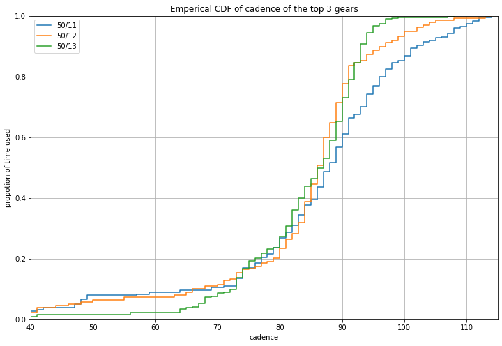

```python
def plot_ecdf_cadence_top3_gears(df):
    data_50_11 = df[df.gear=="50/11"]
    data_50_12 = df[df.gear=="50/12"]
    data_50_13 = df[df.gear=="50/13"]

    plt.figure(figsize=(12,8))
    sns.ecdfplot(data=data_50_11, x="cadence", label=f"50/11", weights=data_50_11.duration)
    sns.ecdfplot(data=data_50_12, x="cadence", label=f"50/12", weights=data_50_12.duration)
    sns.ecdfplot(data=data_50_13, x="cadence", label=f"50/13", weights=data_50_13.duration)

    plt.title("Emperical CDF of cadence of the top 3 gears")
    plt.ylabel("propotion of time used")
    plt.legend()
    plt.xlim(40, 115)
    plt.grid()
    plt.show()


plot_ecdf_cadence_top3_gears(road_ride)
```

The cadence at percentile 80% is higher for the 50/11 gear. This is indication that from time to time the rider has to increase the cadence above optimum levels to keep up with the speed. The code below calculates the time not optimal cadence is used. The not optimal cadence is defined as >95rpm by the point where the ECDF plot starts to differ from the neighbouring gears.

```python
time_top_gear_high_cadence = road_ride[(road_ride.gear == "50/11") & (road_ride.cadence > 95)].duration.sum()
time_gears_used = powered_data.duration.sum()
percentage_too_high_cadence = 100 * (time_top_gear_high_cadence / time_gears_used)
print(f"The 50/11 gear is used for {time_top_gear_high_cadence}s with too high cadence, or {percentage_too_high_cadence:.2f}%")
```

```
The 50/11 gear is used for 104.0s with too high cadence, or 0.61%
```

The time riding with too high cadence is not very long. **It is better to have a little higher top gear, but it is not essential.**

## Gear steps

Gear steps is another important characteristic. There are 12 speed to choose from. The cassette manufacturers optimize the teeth number to suit the typical rider. It is considered that cassettes are already optimized in terms of gear steps. Tuning the number of teeth of each cog is outside the scope of this analysis.

## Gear range selection for 1x12 system

So far we understood the low and high limits of the current setup are appropriate. We can calculate the cassette range and target the same range with the new setup.

```python
cassette_12_range = (50/11) / (34/28)
cassette_12_range
```

```
3.743315508021391
```

There are a couple of cassette on the market with similar range:

- 11-46 with 4.18 range (https://www.bike24.com/p2327912.html?menu=1000,1868,1869,1874)
- 10-36 with 3.60 range (https://www.bike24.com/p2464280.html?menu=1000,1868,1869,1874)
- 10-33 with 3.33 range (https://www.bike24.com/p2313279.html?menu=1000,1868,1869,1874)

The 10-36 cassette is selected as the range is closest to the current setup The closest chainring size is with 46 teeth.

```python
gear_ratios_2_11 = [34/28, 34/25, 34/23, 34/21, 34/19, 34/17, 34/15,
            50/21, 50/19, 50/17, 50/15, 50/14, 50/13 , 50/12, 50/11]
```

```python
COGS12 = np.array([10, 11, 12, 13, 15, 17, 19, 21, 24, 28, 32, 36])
CHAINRING12 = 46
# gear_ratios_12 = CHAINRING12 / COGS12
# gear_ratios_12 = gear_ratios_12[::-1]
# gear_ratios_12
gears_12 = {}
for cog in COGS12[::-1]:
    gears_12[f"{CHAINRING12}/{cog}"] = CHAINRING12 / cog
gears_12
```

```
{'46/36': 1.2777777777777777,
 '46/32': 1.4375,
 '46/28': 1.6428571428571428,
 '46/24': 1.9166666666666667,
 '46/21': 2.1904761904761907,
 '46/19': 2.4210526315789473,
 '46/17': 2.7058823529411766,
 '46/15': 3.066666666666667,
 '46/13': 3.5384615384615383,
 '46/12': 3.8333333333333335,
 '46/11': 4.181818181818182,
 '46/10': 4.6}
```

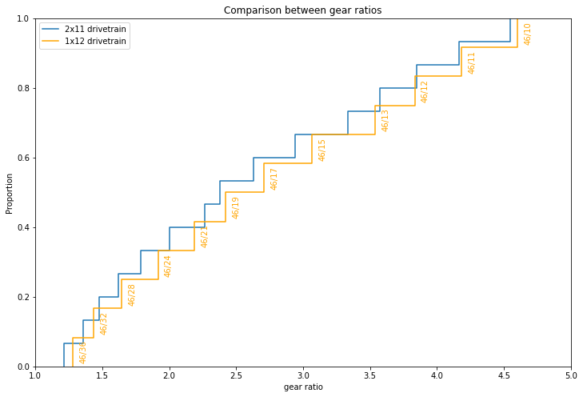

```python
plt.figure(figsize=(12,8))
# sns.ecdfplot(data=road_ride, x="gear_ratio", label=f"Emperical CDF", weights=road_ride.distance_increment)
sns.ecdfplot(data=gear_ratios_2_11, label=f"2x11 drivetrain")
sns.ecdfplot(data=gears_12, label=f"1x12 drivetrain",  color = "orange")
y = 1 / 12 - 0.07
for k, v in gears_12.items():
    plt.text(v+0.05, y, k, rotation=90, color = "orange")
    y += 1/12
plt.title("Comparison between gear ratios")
plt.xlabel("gear ratio")
plt.xlim(1, 5)
plt.legend()
plt.show()
```

As seen on the graph above, the proposed 1x12 setup offers a little faster gears. Motivation for choosing 46t instead of 44t:

- the 50/11 gear was not high enough for some sprints. Selecting 44t chainring will reduce the top gear significantly.
- the 34/28 gear usage is small. In steep climbs, the rider always has the option to pedal out of the saddle.

The steps between gears are bigger, as expected. The code below analyses the expected usage of the proposed setup.

```python
def calculate_suitable_gear_1_12(ratio) -> str:
    """
    returns the most proper gear combo with 1x12 setup

    """
    if ratio == 0 or pd.isna(ratio):
        return "stationary"
    if ratio > gears_12["46/10"] + 0.5 * (gears_12["46/10"] - gears_12["46/11"]):
        return "freewheeling"
    front_teeth = CHAINRING12
    diffrence_to_possible_ratios = np.abs(front_teeth / COGS12 - ratio)
    cog_index = diffrence_to_possible_ratios.argmin()
    rear_teeth = COGS12[cog_index]
    return f"{front_teeth}/{rear_teeth}"


#unit test of the function
x = np.linspace(0, 5, 40)
calculate_suitable_gear_1_12_v = np.vectorize(calculate_suitable_gear_1_12)
expected_result = ['stationary', '46/36', '46/36', '46/36', '46/36', '46/36', '46/36',
                   '46/36', '46/36', '46/36', '46/36', '46/32', '46/32', '46/28',
                   '46/24', '46/24', '46/24', '46/21', '46/19', '46/19', '46/17',
                   '46/17', '46/17', '46/15', '46/15', '46/15', '46/13', '46/13',
                   '46/13', '46/12', '46/12', '46/12', '46/11', '46/11', '46/11',
                   '46/10', '46/10', '46/10', 'freewheeling', 'freewheeling']
assert((calculate_suitable_gear_1_12_v(x) == expected_result).all())
```

```python
def add_12x_gears(df):
    """
    adds a colum with the most proper gear for a 2x11 setup.
    the column is ordered categorical
    """
    df["gear_12"] = df.gear_ratio.apply(calculate_suitable_gear_1_12)
    used_gears = df["gear_12"].unique()
    all_gears = ['stationary'] + list(gears_12.keys()) + ['freewheeling']
    ordered_gears = [el for el in all_gears if el in used_gears]
    df.gear_12 = pd.Categorical(df.gear_12, ordered=True, categories = ordered_gears)
    return df


road_ride = add_12x_gears(road_ride)
```

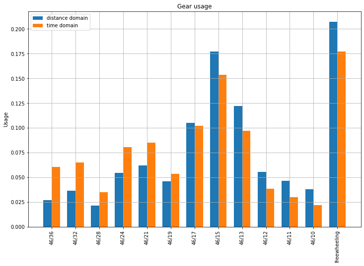

```python
def plot_12x_gear_usage(df):
    gear_stats_12 = df.groupby("gear_12").sum()[["distance_increment", "duration"]]
    gear_stats_12.columns = ["distance", "duration"]
    gear_stats_12 = gear_stats_12.drop('stationary')
    plot_gear_usage(gear_stats_12)


plot_12x_gear_usage(road_ride)
```

The usage of the most preferred gear has slightly increased to above 15%. This is normal as the total number of gears has been decreased. No premature wear is expected.

# Analysis of a second road ride

```python
road_ride2 = get_all_road_rides(r"data - second ride", single=True)
# https://www.strava.com/activities/4946228864
# road_ride2
```

```
2021-03-14-09-52-27.fit:
                    average speed = 7.544886554111481
                    average cadence = 60.7034085335949
                    distance = 172173.44
```

```python
road_ride2 = add_duration(road_ride2)
road_ride2 = add_distance_increment(road_ride2)
road_ride2 = add_speed_mult_duration(road_ride2)
road_ride2 = remove_v_mult_t_outliers(road_ride2)
road_ride2 = add_slope(road_ride2)
road_ride2 = add_gear_ratios(road_ride2)
road_ride2 = add_gears(road_ride2)
road_ride2
```

|  | latitude | longitude | lap | altitude | timestamp | heart_rate | cadence | speed | distance | temperature | duration | distance_increment | slope | gear_ratio | gear |
| --- | --- | --- | --- | --- | --- | --- | --- | --- | --- | --- | --- | --- | --- | --- | --- |
| 0 | 42.669191 | 23.297802 | 1 | 587.8 | 2021-03-14 07:52:27+00:00 | 83.0 | 0.0 | 4.983 | 4.98 | 19 | NaN | NaN | -0.007163 | inf | freewheeling |
| 1 | 42.669165 | 23.297846 | 1 | 587.8 | 2021-03-14 07:52:28+00:00 | 86.0 | 0.0 | 5.067 | 10.05 | 19 | 1.0 | 5.07 | -0.007015 | inf | freewheeling |
| 2 | 42.669127 | 23.297883 | 1 | 587.6 | 2021-03-14 07:52:29+00:00 | 89.0 | 0.0 | 5.085 | 15.13 | 19 | 1.0 | 5.08 | -0.006866 | inf | freewheeling |
| 3 | 42.669083 | 23.297910 | 1 | 587.4 | 2021-03-14 07:52:30+00:00 | 90.0 | 0.0 | 5.337 | 20.47 | 19 | 1.0 | 5.34 | -0.006709 | inf | freewheeling |
| 4 | 42.669040 | 23.297928 | 1 | 587.4 | 2021-03-14 07:52:31+00:00 | 94.0 | 50.0 | 5.524 | 26.00 | 19 | 1.0 | 5.53 | -0.006547 | 3.149074 | 50/15 |
| ... | ... | ... | ... | ... | ... | ... | ... | ... | ... | ... | ... | ... | ... | ... | ... |
| 8228 | 42.667535 | 23.303812 | 36 | 630.4 | 2021-03-14 14:53:55+00:00 | 115.0 | 52.0 | 3.154 | 172134.56 | 16 | 4.0 | 12.14 | -0.072768 | 1.728851 | 34/19 |
| 8229 | 42.667481 | 23.303721 | 36 | 630.6 | 2021-03-14 14:53:58+00:00 | 117.0 | 52.0 | 3.499 | 172144.60 | 16 | 3.0 | 10.04 | -0.073458 | 1.917961 | 34/17 |
| 8230 | 42.667422 | 23.303529 | 36 | 630.6 | 2021-03-14 14:54:04+00:00 | 120.0 | 48.0 | 2.883 | 172162.74 | 16 | 6.0 | 18.14 | -0.074706 | 1.711995 | 34/19 |
| 8231 | 42.667419 | 23.303503 | 36 | 630.6 | 2021-03-14 14:54:05+00:00 | 121.0 | 48.0 | 2.398 | 172165.14 | 16 | 1.0 | 2.40 | -0.074871 | 1.423990 | 34/23 |
| 8233 | 42.667430 | 23.303410 | 36 | 630.0 | 2021-03-14 14:54:22+00:00 | 124.0 | 0.0 | 0.000 | 172173.44 | 16 | 10.0 | 0.00 | -0.075442 | NaN | stationary |

8214 rows × 15 columns

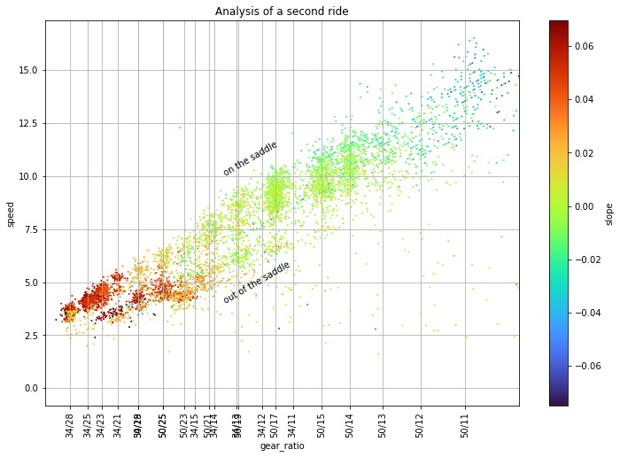

```python
ax = plot_three_columns(road_ride2, "speed", "slope")
ax.text(2.5, 4, "out of the saddle", rotation=30)
ax.text(2.5, 10, "on the saddle", rotation=30)
plt.title("Analysis of a second ride")
plt.show()
```

The graph above confirms all observations done for the first ride:

- clustering of the records around the predefined gears
- two linear regressions for on and off the saddle efforts
- resting at the lowest gear
- not high enough top gear (only few points, metrics will be evaluated)

On this ride, the steepest climb has been attacked with out of the saddle effort on gears 34/23 and 34/21, as suggested before.

```python
plot_border_gear_usage(road_ride2)
```

```
The 34/28 gear is used for 844.0s with high heart rate, or 4.69%
The 50/11 gear is used for 388.0s, or 2.16%
```

This ride has a higher usage of the slowest gear, but still the overall time is low.

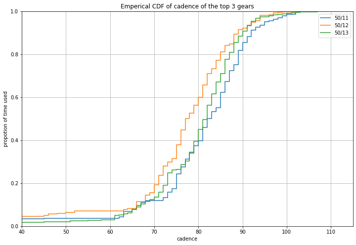

```python
plot_ecdf_cadence_top3_gears(road_ride2)
```

In this, second ride, the lack of top gear is not so pronounced.

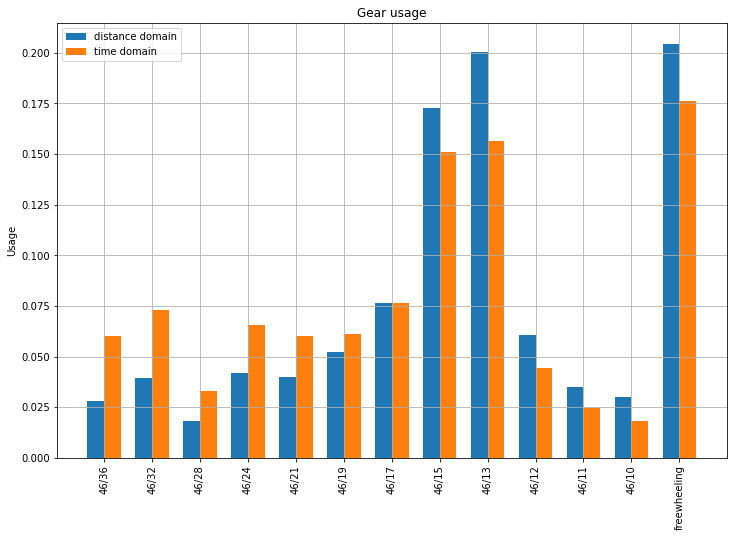

```python
road_ride2 = add_12x_gears(road_ride2)
plot_12x_gear_usage(road_ride2)
```

# Conclusion

The rider could upgrade the 2x11 setup with 1x12 without expected performance loss. The most suitable configuration, for his riding style, is to use chainring with 46 teeth and cassette with 10-36 range (10, 11, 12, 13, 15,17,19, 21, 24, 28, 32, 36). There would be a small shift to higher gear ratio. It was preferred because it was found the highest gear is not high enough and the lowest gear was not so essential.

# Motivation for further research

This study is focused on one rider on two rides only, but it could be expanded to cover a large number of riders and rides. 1x12 systems are entering the road riding and gear system suppliers are competing to offer the best product and get bigger market share. Possible marketing strategy could include:

- Deploy a web platform where riders can upload log files, like the analyzed here. Riders would get free analysis, the manufacturer will build database. Such logging devices are pretty common and files are readily available. No investment needed.
- The database will be used to perform analysis to select teeth number for the cassette.
- Such cassette(s) will be developed and offered to the market
- The web platform will also propose a best cassette based on uploaded log files. The platform will include several graphs and statistics to convince the rider what is the best choice for him/her.

# References

https://www.youtube.com/watch?v=wrfSEHrB9Wo

https://towardsdatascience.com/parsing-fitness-tracker-data-with-python-a59e7dc17418

https://stackoverflow.com/questions/15862066/gradient-in-noisy-data-python